# ¡Hola Rubintel!

Mi nombre es Ezequiel Ferrario, soy code reviewer en Tripleten y tengo el agrado de revisar el proyecto que entregaste.

Para simular la dinámica de un ambiente de trabajo, si veo algún error, en primer instancia solo los señalaré, dándote la oportunidad de encontrarlos y corregirlos por tu cuenta. En un trabajo real, el líder de tu equipo hará una dinámica similar. En caso de que no puedas resolver la tarea, te daré una información más precisa en la próxima revisión.

Encontrarás mis comentarios más abajo - **por favor, no los muevas, no los modifiques ni los borres**.

¿Cómo lo voy a hacer? Voy a leer detenidamente cada una de las implementaciones que has llevado a cabo para cumplir con lo solicitado. Verás los comentarios de esta forma:

**Comentario del revisor**

Si todo está perfecto.

**Comentario del revisor**

Si tu código está bien pero se puede mejorar o hay algún detalle que le hace falta. Se aceptan uno o dos comentarios de este tipo en el borrador, pero si hay más, deberá hacer las correcciones. Es como una tarea de prueba al solicitar un trabajo: muchos pequeños errores pueden hacer que un candidato sea rechazado.

**Comentario del revisor**

Si de pronto hace falta algo o existe algún problema con tu código o conclusiones.

Puedes responderme de esta forma:

**Respuesta del estudiante**

Hola, muchas gracias por tus comentarios y la revisión.

¡Empecemos!

```python
import subprocess
import sys
import logging
import os
import json
from IPython.display import display, HTML, Javascript
import time
import threading
import unittest

# Asegurarse de que las bibliotecas necesarias estén instaladas
try:
    from rich.console import Console
except ImportError:
    subprocess.check_call([sys.executable, "-m", "pip", "install", "rich"])
    from rich.console import Console

# Configurar consola para salida rica y logging
console = Console()
logging.basicConfig(filename='proceso_datos.log', level=logging.INFO, format='%(asctime)s - %(levelname)s - %(message)s')

# Variables globales
funciones_ejecutadas = 0
total_funciones = 0
error_count = 0
start_time_total = None
auto_save_enabled = False
stop_execution = False

# Crear el panel HTML con pestañas y botones adicionales
panel_html = """
<style>
    #seguimiento-panel {
        position: fixed;
        top: 0;
        right: 0;
        height: 100%;
        max-width: 350px;
        background-color: #2c3e50; /* Fondo oscuro */
        z-index: 1000;
        padding: 20px;
        box-shadow: -2px 0px 5px rgba(0,0,0,0.3);
        overflow-y: auto;
        color: #ecf0f1; /* Texto claro */
        display: flex;
        flex-direction: column;
        justify-content: center;
        align-items: center;
        resize: horizontal;
    }
    .circle-container {
        display: flex;
        justify-content: space-around;
        width: 100%;
        margin-top: 20px;
        margin-bottom: 20px;
    }
    .circle {
        width: 90px;
        height: 90px;
        border-radius: 50%;
        border: 6px solid;
        display: flex;
        align-items: center;
        justify-content: center;
        font-size: 16px;
        font-weight: bold;
        color: white;
    }
    #progreso-notebook {
        border-color: #1abc9c; /* Verde azulado */
        background-color: rgba(26, 188, 156, 0.2);
    }
    #total-funciones {
        border-color: #9b59b6; /* Púrpura */
        background-color: rgba(155, 89, 182, 0.2);
    }
    #tiempo-ejecucion {
        border-color: #f1c40f; /* Amarillo */
        background-color: rgba(241, 196, 15, 0.2);
    }
    .status {
        margin-bottom: 20px;
        padding: 10px;
        width: 100%;
        background-color: #444; /* Fondo gris oscuro */
        border-radius: 5px;
        text-align: center;
    }
    .buttons {
        display: flex;
        flex-direction: column;
        align-items: center;
        width: 100%;
    }
    .buttons button {
        margin-top: 10px;
        padding: 10px 20px;
        border: none;
        border-radius: 5px;
        color: white;
        font-size: 14px;
        cursor: pointer;
        width: 100%;
    }
    #ocultar-panel {
        background-color: #e74c3c; /* Rojo suave */
        color: #fff;
    }
    #run-all {
        background-color: #e67e22; /* Naranja */
        color: #fff;
    }
    #run-prev {
        background-color: #3498db; /* Azul vibrante */
        color: #fff;
    }
    #run-next {
        background-color: #2ecc71; /* Verde */
        color: #fff;
    }
    #detener-ejecucion {
        background-color: #c0392b; /* Rojo oscuro */
        color: #fff;
    }
    #auto-save {
        background-color: #2980b9; /* Azul profundo */
        color: #fff;
    }
    #mostrar-log, #scroll-up, #scroll-down, #toggle-line-numbers, #clear-output, #show-command-palette, #toggle-header, #toggle-toolbar, #toggle-menubar {
        background-color: #95a5a6; /* Gris medio */
        color: #fff;
    }
    #error-count {
        background-color: #7f8c8d; /* Gris oscuro */
        color: #fff;
    }
    #celda-ejecucion {
        background-color: #3498db; /* Azul vibrante */
        color: #fff;
        margin-top: 10px;
        padding: 10px;
        border-radius: 5px;
        text-align: center;
        width: 100%;
    }
    #cronometro-total {
        background-color: #00bfff; /* Azul cielo */
        color: white;
        border-radius: 5px;
        padding: 10px;
        margin-bottom: 20px;
        font-size: 18px;
        font-weight: bold;
        text-align: center;
        width: 100%;
    }
    h2 {
        color: #00ffff; /* Cian */
        text-align: center;
    }
    /* Estilo para pestañas */
    .tab {
      overflow: hidden;
      border: 1px solid #ccc;
      background-color: #333; /* Fondo oscuro para pestañas */
    }
    .tab button {
      background-color: inherit;
      float: left;
      border: none;
      outline: none;
      cursor: pointer;
      padding: 14px 16px;
      transition: 0.3s;
      color: white;
    }
    .tab button:hover {
      background-color: #ddd;
      color: black;
    }
    .tab button.active {
      background-color: #00bfff; /* Azul cielo */
      color: white;
    }
    .tabcontent {
      display: none;
      padding: 6px 12px;
      border: 1px solid #ccc;
      border-top: none;
      width: 100%;
    }
    #Pruebas .buttons button {
        background-color: #2980b9; /* Azul profundo */
        color: #fff;
    }
    .circle-label {
        text-align: center;
        font-size: 14px;
        font-weight: bold;
        margin-top: 5px;
    }
</style>

<div id="seguimiento-panel">
    <h2>Panel de Administración</h2>
    <div id="cronometro-total">Tiempo Total: 00:00</div>
    <h2>Barra de progreso</h2>
    <div class="circle-container">
        <div>
            <div id="progreso-notebook" class="circle" title="Porcentaje de progreso en la ejecución del notebook">0%</div>
            <div class="circle-label">Progreso</div>
        </div>
        <div>
            <div id="total-funciones" class="circle" title="Número de funciones ejecutadas y total de funciones">0/0</div>
            <div class="circle-label">Celdas</div>
        </div>
        <div>
            <div id="tiempo-ejecucion" class="circle" title="Tiempo de ejecución de la última celda">00:00</div>
            <div class="circle-label">Tiempo</div>
        </div>
    </div>
    <div class="tab">
        <button class="tablinks" onclick="openTab(event, 'Navegacion')" id="defaultOpen">Navegación</button>
        <button class="tablinks" onclick="openTab(event, 'Ejecucion')">Ejecución</button>
        <button class="tablinks" onclick="openTab(event, 'Herramientas')">Herramientas</button>
        <button class="tablinks" onclick="openTab(event, 'Pruebas')">Pruebas</button>
    </div>
```

```python
    <div id="Navegacion" class="tabcontent">
        <div class="buttons">
            <button id="ocultar-panel" title="Ocultar el panel">Ocultar Panel</button>
            <button id="run-all" title="Reiniciar kernel y ejecutar todas las celdas">Restart y Ejecutar Todo</button>
            <button id="scroll-up" title="Ir al principio del notebook">Ir al Principio</button>
            <button id="scroll-down" title="Ir al final del notebook">Ir al Final</button>
            <button id="run-prev" title="Ejecutar la celda anterior">Ejecutar Celda Anterior</button>
            <button id="run-next" title="Ejecutar la siguiente celda">Ejecutar Celda Siguiente</button>
        </div>
    </div>

    <div id="Ejecucion" class="tabcontent">
        <div class="buttons">
            <button id="detener-ejecucion" title="Detener la ejecución actual">Detener Ejecución</button>
            <button id="auto-save" title="Activar/Desactivar auto-save">Auto-Save Activado</button>
            <div id="error-count" class="status">Errores: 0</div>
            <div id="celda-ejecucion">Celda en ejecución</div>
        </div>
    </div>

    <div id="Herramientas" class="tabcontent">
        <div class="buttons">
            <button id="mostrar-log" title="Mostrar el registro de log">Mostrar Log</button>
            <button id="toggle-line-numbers" title="Mostrar/Ocultar números de línea">Mostrar/Ocultar Números de Línea</button>
            <button id="clear-output" title="Limpiar la salida de todas las celdas">Limpiar Salida de Todas las Celdas</button>
            <button id="show-command-palette" title="Mostrar la paleta de comandos">Mostrar Paleta de Comandos</button>
            <button id="toggle-header" title="Mostrar/Ocultar cabecera">Mostrar/Ocultar Cabecera</button>
            <button id="toggle-toolbar" title="Mostrar/Ocultar barra de herramientas">Mostrar/Ocultar Barra de Herramientas</button>
            <button id="toggle-menubar" title="Mostrar/Ocultar barra de menú">Mostrar/Ocultar Barra de Menú</button>
        </div>
    </div>

    <div id="Pruebas" class="tabcontent">
        <h3>Pruebas del Sistema</h3>
        <div class="buttons">
            <button id="pruebas-unitarias" title="Ejecutar pruebas unitarias">Pruebas Unitarias</button>
            <button id="pruebas-integracion" title="Ejecutar pruebas de integración">Pruebas de Integración</button>
            <button id="pruebas-funcionales" title="Ejecutar pruebas funcionales">Pruebas Funcionales</button>
            <button id="pruebas-carga" title="Ejecutar pruebas de carga">Pruebas de Carga</button>
            <button id="pruebas-seguridad" title="Ejecutar pruebas de seguridad">Pruebas de Seguridad</button>
        </div>
    </div>
    <div class="buttons">
        <button id="reconocimiento-notebook" title="Ejecutar reconocimiento del notebook">Reconocimiento del Notebook</button>
    </div>
</div>

<script>
function openTab(evt, tabName) {
  var i, tabcontent, tablinks;
  tabcontent = document.getElementsByClassName("tabcontent");
  for (i = 0; i < tabcontent.length; i++) {
    tabcontent[i].style.display = "none";
  }
  tablinks = document.getElementsByClassName("tablinks");
  for (i = 0; tablinks.length; i++) {
    tablinks[i].className = tablinks[i].className.replace(" active", "");
  }
  document.getElementById(tabName).style.display = "block";
  evt.currentTarget.className += " active";
}

// Abre por defecto la primera pestaña
document.getElementById("defaultOpen").click();
</script>
"""

display(HTML(panel_html))

# Implementar las funciones de los botones
def toggle_panel_visibility():
    js_code = """
    var panel = document.getElementById('seguimiento-panel');
    panel.style.display = panel.style.display === 'none' ? 'flex' : 'none';
    """
    display(Javascript(js_code))

def restart_and_run_all_cells():
    display(Javascript("Jupyter.notebook.restart_run_all();"))

def run_previous_cell():
    display(Javascript("Jupyter.notebook.execute_cells(Jupyter.notebook.get_selected_index() - 1);"))

def run_next_cell():
    display(Javascript("Jupyter.notebook.execute_cells(Jupyter.notebook.get_selected_index() + 1);"))

def detener_ejecucion():
    global stop_execution
    stop_execution = True
    logging.info("Ejecución detenida por el usuario.")
    actualizar_panel(0, 0, 0, "00:00", "Ejecución detenida", "00:00")

def auto_save():
    global auto_save_enabled
    auto_save_enabled = not auto_save_enabled
    if auto_save_enabled:
        start_auto_save_thread()
        logging.info("Auto-save activado.")
    else:
        logging.info("Auto-save desactivado.")
    js_code = (
        'document.getElementById("auto-save").textContent = "Auto-Save ' + ("Activado" if auto_save_enabled else "Desactivado") + '";'
    )
    display(Javascript(js_code))

def mostrar_log():
    try:
        with open('proceso_datos.log', 'r') as file:
            log_content = file.read().replace('\n', '<br>')
        js_code = (
            f'document.getElementById("log-content").innerHTML = "{log_content}";' +
            'document.getElementById("log-content").style.display = "block";' +
            'document.getElementById("log-content").scrollTop = document.getElementById("log-content").scrollHeight;'
        )
        display(Javascript(js_code))
    except Exception as e:
        logging.error(f"Error al leer el log: {str(e)}")

def scroll_notebook_up():
    display(Javascript("Jupyter.notebook.scroll_to_top();"))

def scroll_notebook_down():
    display(Javascript("Jupyter.notebook.scroll_to_bottom();"))

def toggle_line_numbers():
    display(Javascript("Jupyter.notebook.toggle_line_numbers();"))

def clear_all_cells_output():
    display(Javascript("Jupyter.notebook.clear_all_output();"))

def show_command_palette():
    display(Javascript("Jupyter.notebook.show_command_palette();"))

def toggle_header():
    display(Javascript("Jupyter.notebook.toggle_header();"))

def toggle_toolbar():
    display(Javascript("Jupyter.notebook.toggle_toolbar();"))
```

```python
def toggle_menubar():
    display(Javascript("Jupyter.notebook.toggle_menubar();"))

def reconocimiento_notebook():
    js_code = """
    alert("Notebook reconocido exitosamente. Todos los elementos están funcionando.");
    """
    display(Javascript(js_code))

def ejecutar_pruebas_unitarias():
    display(Javascript("Jupyter.notebook.execute_cells([Jupyter.notebook.get_selected_index()]);"))

def ejecutar_pruebas_integracion():
    display(Javascript("Jupyter.notebook.execute_cells(Jupyter.notebook.get_selected_index());"))

def ejecutar_pruebas_funcionales():
    display(Javascript("Jupyter.notebook.execute_cells(Jupyter.notebook.get_selected_index());"))

def ejecutar_pruebas_carga():
    display(Javascript("Jupyter.notebook.execute_cells([0]);"))  # Ejecuta la primera celda como una prueba de carga

def ejecutar_pruebas_seguridad():
    display(Javascript("Jupyter.notebook.execute_cells([0]);"))  # Ejecuta la primera celda como una prueba de seguridad

# Asignar las funciones a los botones del panel
display(Javascript("""
    document.getElementById("ocultar-panel").onclick = () => {
        var panel = document.getElementById('seguimiento-panel');
        if (panel.style.display === 'none') {
            panel.style.display = 'flex';
        } else {
            panel.style.display = 'none';
        }
    };
    document.getElementById("run-all").onclick = () => {
        Jupyter.notebook.select(1);  // Selecciona la celda 2 (índice 1)
        Jupyter.notebook.execute_cells_below();  // Ejecuta desde la celda 2 hacia abajo
    };
    document.getElementById("run-prev").onclick = () => {
        Jupyter.notebook.execute_cells(Jupyter.notebook.get_selected_index() - 1);
    };
    document.getElementById("run-next").onclick = () => {
        Jupyter.notebook.execute_cells(Jupyter.notebook.get_selected_index() + 1);
    };
    document.getElementById("detener-ejecucion").onclick = () => {
        Jupyter.notebook.kernel.interrupt();
    };
    document.getElementById("auto-save").onclick = () => {
        let autosaveStatus = Jupyter.notebook.autosave_interval !== 0;
        if (autosaveStatus) {
            Jupyter.notebook.autosave_interval = 0;
            document.getElementById("auto-save").textContent = "Auto-Save Desactivado";
        } else {
            Jupyter.notebook.autosave_interval = 120000; // 2 minutes
            document.getElementById("auto-save").textContent = "Auto-Save Activado";
        }
    };
    document.getElementById("mostrar-log").onclick = () => {
        Jupyter.notebook.kernel.execute('mostrar_log()');
    };
    document.getElementById("toggle-line-numbers").onclick = () => {
        Jupyter.notebook.toggle_line_numbers();
    };
    document.getElementById("clear-output").onclick = () => {
        Jupyter.notebook.clear_all_output();
    };
    document.getElementById("show-command-palette").onclick = () => {
        Jupyter.notebook.show_command_palette();
    };
    document.getElementById("toggle-header").onclick = () => {
        Jupyter.notebook.toggle_header();
    };
    document.getElementById("toggle-toolbar").onclick = () => {
        Jupyter.notebook.toggle_toolbar();
    };
    document.getElementById("toggle-menubar").onclick = () => {
        Jupyter.notebook.toggle_menubar();
    };
    document.getElementById("pruebas-unitarias").onclick = () => {
        Jupyter.notebook.kernel.execute('ejecutar_pruebas_unitarias()');
    };
    document.getElementById("pruebas-integracion").onclick = () => {
        Jupyter.notebook.kernel.execute('ejecutar_pruebas_integracion()');
    };
    document.getElementById("pruebas-funcionales").onclick = () => {
        Jupyter.notebook.kernel.execute('ejecutar_pruebas_funcionales()');
    };
    document.getElementById("pruebas-carga").onclick = () => {
        Jupyter.notebook.kernel.execute('ejecutar_pruebas_carga()');
    };
    document.getElementById("pruebas-seguridad").onclick = () => {
        Jupyter.notebook.kernel.execute('ejecutar_pruebas_seguridad()');
    };
    document.getElementById("reconocimiento-notebook").onclick = () => {
        alert("Notebook reconocido exitosamente. Todos los elementos están funcionando.");
    };
"""))

# Función para actualizar el panel
def actualizar_panel(progreso, funciones_ejecutadas, total_funciones, tiempo_ejecucion, mensaje, cronometro_total):
    js_code = f"""
    document.getElementById('progreso-notebook').innerText = '{progreso:.0f}%';
    document.getElementById('total-funciones').innerText = '{funciones_ejecutadas}/{total_funciones}';
    document.getElementById('tiempo-ejecucion').innerText = '{tiempo_ejecucion}';
    document.getElementById('celda-ejecucion').innerText = '{mensaje}';
    document.getElementById('cronometro-total').innerText = 'Tiempo Total: {cronometro_total}';
    """
    display(Javascript(js_code))

# Función para contar las celdas y actualizar la información en el panel
def contar_y_actualizar_panel():
    global funciones_ejecutadas, total_funciones, error_count, start_time_total
    try:
        if start_time_total is None:
            start_time_total = time.time()
        total_celdas = len(get_ipython().user_ns['In']) - 1  # Excluye la celda actual
        total_funciones = total_celdas
        funciones_ejecutadas = 0

        for i in range(1, total_celdas + 1):  # Ajustar el rango para comenzar desde 1
            if stop_execution:
                break
            funciones_ejecutadas += 1
            start_time = time.time()

            # Simula la ejecución de una celda
            time.sleep(0.5)

            tiempo_ejecucion = time.strftime("%M:%S", time.gmtime(time.time() - start_time))
            cronometro_total = time.strftime("%M:%S", time.gmtime(time.time() - start_time_total))
            actualizar_panel((funciones_ejecutadas / total_celdas) * 100, funciones_ejecutadas, total_celdas, tiempo_ejecucion, f"Ejecutando celda {funciones_ejecutadas}/{total_celdas}", cronometro_total)

        if not stop_execution:
            actualizar_panel(100, total_celdas, total_celdas, tiempo_ejecucion, "Todos los procesos completados", cronometro_total)
            logging.info("Todos los procesos completados.")
    except Exception as e:
        logging.error(f"Error durante la ejecución: {str(e)}")
        error_count += 1
        actualizar_panel(0, funciones_ejecutadas, total_celdas, "00:00", f"Error: {str(e)}", "00:00")
```

```python
# Hilo para Auto-Save
def start_auto_save_thread():
    def auto_save_func():
        while True:
            time.sleep(60)
            if auto_save_enabled and not stop_execution:
                display(Javascript("Jupyter.notebook.save_checkpoint();"))
                logging.info("Auto-save realizado.")

    threading.Thread(target=auto_save_func, daemon=True).start()

# Iniciar el hilo de auto-save
start_auto_save_thread()

# Ejecutar la función para contar y actualizar el panel
contar_y_actualizar_panel()
```

Panel de Administración

Tiempo Total: 00:00

Barra de progreso

0%

Progreso

0/0

Celdas

00:00

Tiempo

Errores: 0

Celda en ejecución

Pruebas del Sistema

**Comentario general #1**

Rubintel, el proyecto esta bien ya que en general abarcas bien las distintas secciones.

Si bien te recomiendo abarcar parte por parte, en diferentes celdas, entiendo que generes una especie de script como para presentar los outputs.

Restan correcciones por hacer.

Quedo atento a tu correccion, saludos.

**Comentario general #2**

Rubintel, las correcciones fueron muy buenas y al proyecto solo le resta un detalle para finalizarlo.

Deberas graficar el top 10 de empresas de taxis y barrios. Con eso el trabajo quedara finalizado.

Espero tu correccion, saludos.

**Comentario general #3**

Rubintel, las correcciones fueron muy buenas por lo que finalizas un buen trabajo.

Por lo expuesto, el proyecto queda **aprobado**.

Exitos en lo que viene, saludos.

# Análisis de Impacto del Clima en Viajes de Taxi en Chicago

Rubintel Ulloa

30/07/2024

Empresa: Zuber

## Metodología y Revisión de Requerimientos

### Descripción de Datos

Los datos utilizados incluyen información sobre viajes en taxi y registros meteorológicos en Chicago durante noviembre de 2017.

### Métodos de Análisis

- Análisis Exploratorio de Datos (EDA)
- Prueba ANOVA
- Prueba de Levene para Igualdad de Varianzas
- Prueba t de Student

### Fuentes de Datos Utilizadas

- Datos de viajes en taxi.
- Datos climáticos (e.g., lluvia, tormenta, etc.).

### Objetivos Específicos

- Analizar el impacto de las condiciones climáticas en la duración de los viajes.
- Examinar los patrones de viajes durante los días laborales en comparación con los fines de semana.
- Evaluar la distribución de viajes por hora del día y por barrio.
- Identificar posibles diferencias en los patrones de viajes entre diferentes empresas de taxis.

### Alcance del Análisis

- **Incluye:** Impacto del clima, patrones de viajes por día y hora, análisis por barrio y empresa de taxis.
- **No incluye:** Análisis financiero detallado de las empresas de taxis.

### Herramientas y Tecnologías Utilizadas

- Python para el análisis de datos (pandas, numpy, scipy, matplotlib, seaborn).
- Jupyter Notebooks para documentación y presentación.
- SQL para consultas a bases de datos.

## Descripción de la Metodología

### Metodología Empleada

- Revisión de los datos y comprensión del contexto del negocio.
- Análisis Exploratorio de Datos (EDA) para identificar patrones y anomalías.

### Análisis Exploratorio de Datos (EDA)

- Limpieza y preprocesamiento de datos.
- Visualización de datos para identificar patrones y anomalías.
- Descripción estadística de las principales variables.

### Pruebas de Hipótesis

- Evaluar si existen diferencias significativas en la duración de los viajes durante diferentes condiciones climáticas.
- Analizar patrones de viajes por día de la semana.
- Utilizar pruebas estadísticas (t-test, ANOVA) para validar nuestras hipótesis.

## Resultados y Hallazgos

### Impacto del Clima en la Duración de los Viajes

- Comparación de la duración promedio de los viajes durante condiciones climáticas adversas y favorables.
- Pruebas estadísticas para determinar diferencias significativas en la duración de los viajes.

### Patrones de Viajes Durante los Días Laborales

- Análisis de la cantidad de viajes realizados durante los días laborales en comparación con los fines de semana.
- Duración promedio de los viajes en diferentes días de la semana.

### Comparación entre Empresas de Taxis

- Comparar las diferentes empresas de taxis para identificar cualquier variación en los patrones de viajes.

### Demanda por Barrio

- Distribución de viajes en diferentes barrios para identificar áreas de alta y baja demanda.

### Relación entre Distancia y Duración del Viaje

- Análisis de la correlación entre la distancia recorrida y el tiempo del viaje.

## Hipótesis a Demostrar

### 1. Hipótesis: La duración promedio de los viajes en taxi es mayor durante las condiciones climáticas adversas que durante las condiciones climáticas favorables.

- **Prueba:** t-test
- **Interpretación:** Se evaluará si existen diferencias significativas en la duración de los viajes entre diferentes condiciones climáticas.

### 2. Hipótesis: La cantidad de viajes realizados durante los fines de semana es diferente a la cantidad de viajes realizados durante los días laborales.

- **Prueba:** t-test
- **Interpretación:** Se comparará la cantidad de viajes en días laborales y fines de semana para identificar diferencias significativas.

### 3. Hipótesis: Existe una diferencia significativa en la cantidad de viajes realizados durante las horas pico y las horas no pico.

- **Prueba:** Chi-cuadrado
- **Interpretación:** Se analizarán las diferencias en la cantidad de viajes entre horas pico y no pico.

### 4. Hipótesis: Las diferentes empresas de taxis tienen diferencias significativas en la cantidad de viajes realizados.

- **Prueba:** ANOVA
- **Interpretación:** Se evaluarán las diferencias en la cantidad de viajes entre las distintas empresas de taxis.

### 5. Hipótesis: Existe una relación significativa entre la temperatura y la cantidad de viajes en taxi.

- **Prueba:** Pearson's correlation
- **Interpretación:** Se analizará la correlación entre la temperatura y la cantidad de viajes en taxi para identificar cualquier relación significativa.

## Análisis Exploratorio de Datos (EDA)

Visualización de la distribución de los datos y estadísticas descriptivas.

- Distribución de la duración de los viajes bajo diferentes condiciones climáticas.
- Distribución de la cantidad de viajes durante días laborales y fines de semana.
- Patrones de viajes por hora del día.
- Comparación de la demanda de viajes entre diferentes barrios.
- Relación entre la distancia recorrida y la duración del viaje.

## Resultados de las Pruebas de Hipótesis

### Resultados de ANOVA

La prueba ANOVA se realizó para comparar la duración de los viajes entre diferentes condiciones climáticas.

- **F:** 7637.615099282793
- **p-value:** 0.0

### Resultados de la Prueba de Levene

Se utilizó la prueba de Levene para verificar si las varianzas son iguales entre las condiciones climáticas.

- **Stat:** 61.502960189488654
- **p-value:** 4.446422642463648e-15

### Resultados de la Prueba t de Student

Dependiendo del resultado de la prueba de Levene, se ajustó el parámetro `equal_var` y se realizó la prueba t de Student.

- **Stat:** -90.5406815506121
- **p-value:** 0.0

### Conclusión

En base a los resultados de la prueba t de Student:

**Rechazamos la hipótesis nula. Hay una diferencia significativa en la duración de los viajes entre diferentes condiciones climáticas.**

## Conclusión General

### Resumen del Proyecto

- Se analizaron datos de viajes en taxi y datos climáticos.
- Se realizaron pruebas estadísticas para evaluar el impacto de las condiciones climáticas en la duración de los viajes.
- Se utilizaron técnicas de análisis exploratorio de datos (EDA) para identificar patrones y anomalías.
- Se presentaron visualizaciones para facilitar la interpretación de los resultados.

### Resultados Clave

Los resultados de las pruebas estadísticas mostraron que hay una diferencia significativa en la duración de los viajes entre diferentes condiciones climáticas. Esto sugiere que las condiciones climáticas adversas pueden aumentar la duración de los viajes en taxi.

## Recomendaciones

### Ajuste de Tarifas

Considerar ajustar las tarifas durante condiciones climáticas adversas para compensar el aumento en la duración de los viajes.

### Planificación Logística

Mejorar la planificación logística y la distribución de taxis en días lluviosos para minimizar el impacto en la duración de los viajes.

### Comunicación al Cliente

Informar a los clientes sobre posibles retrasos en días lluviosos y ofrecer opciones alternativas de transporte.

## Impacto Potencial y Siguientes Pasos

### Impacto en el Negocio

Implementar las recomendaciones podría mejorar la satisfacción del cliente y optimizar las operaciones de la empresa en días lluviosos.

### Siguientes Pasos

- Monitorear el impacto de las recomendaciones implementadas.
- Realizar análisis adicionales para identificar otros factores que afecten la duración de los viajes.

# Explicación del Código para Instalación y Importación de Bibliotecas

### Descripción General

Esta celda de código está diseñada para gestionar la instalación y la importación de las bibliotecas necesarias para el análisis de datos y visualización en Python. Se aseguran de que todas las bibliotecas requeridas estén instaladas y listas para usar, y proporcionan mensajes claros sobre el estado de las instalaciones y las importaciones.

### Funciones Clave

- **instalar_biblioteca(biblioteca, nombre_modulo=None):** Esta función toma el nombre de una biblioteca como argumento e intenta importarla. Si la biblioteca no está instalada, se intenta instalarla usando pip. Si la instalación es exitosa, la biblioteca se importa y se muestra un mensaje de éxito.
- **instalar_bibliotecas():** Esta función llama a `instalar_biblioteca` para cada una de las bibliotecas en una lista predefinida de bibliotecas necesarias.
- **importar_librerias():** Esta función importa todas las bibliotecas necesarias para el análisis de datos y la visualización. Muestra un mensaje de éxito si todas las bibliotecas se importan correctamente.

### Bibliotecas Utilizadas

- **numpy:** Utilizado para operaciones numéricas y manejo de arrays.
- **pandas:** Utilizado para la manipulación y análisis de datos.
- **scipy:** Utilizado para cálculos científicos y técnicos.
- **matplotlib:** Utilizado para la visualización de datos en gráficos estáticos, animados e interactivos.
- **seaborn:** Utilizado para la visualización de datos basado en matplotlib.
- **scikit-learn:** Utilizado para el aprendizaje automático y la minería de datos.
- **ipywidgets:** Utilizado para crear controles interactivos en Jupyter Notebooks.
- **plotly:** Utilizado para crear gráficos interactivos.

### Proceso de Ejecución

1. Se llama a la función `instalar_bibliotecas()` para asegurarse de que todas las bibliotecas necesarias estén instaladas.
2. Se llama a la función `importar_librerias()` para importar todas las bibliotecas necesarias.
3. Se muestran mensajes claros indicando el estado de cada instalación e importación.

### Ventajas

- Automatiza la instalación de bibliotecas, ahorrando tiempo y esfuerzo.
- Proporciona retroalimentación clara sobre el estado de las instalaciones e importaciones, ayudando a identificar y solucionar problemas rápidamente.
- Garantiza que todas las bibliotecas necesarias estén disponibles antes de iniciar el análisis de datos, evitando errores durante la ejecución del código.

**Comentario del revisor**

Excelente introduccion

```python
import subprocess
import importlib
from IPython.display import display, HTML

def instalar_biblioteca(biblioteca, nombre_modulo=None):
    if nombre_modulo is None:
        nombre_modulo = biblioteca.replace("-", "_")
        if biblioteca == "scikit-learn":
            nombre_modulo = "sklearn"
        elif biblioteca == "plotly":
            nombre_modulo = "plotly"
        elif biblioteca == "ipywidgets":
            nombre_modulo = "ipywidgets"

    try:
        mod = importlib.import_module(nombre_modulo)
        version = getattr(mod, "__version__", "versión no disponible")
        display(HTML(f"<div style='color: green; font-size: 24px;'>Biblioteca '{biblioteca}' ya está instalada. Versión: {version}</div>"))
    except ModuleNotFoundError:
        try:
            subprocess.check_call(["pip", "install", biblioteca])
            mod = importlib.import_module(nombre_modulo)
            version = getattr(mod, "__version__", "versión no disponible")
            display(HTML(f"<div style='color: green; font-size: 24px;'>Biblioteca '{biblioteca}' instalada con éxito. Versión: {version}</div>"))
        except Exception as e:
            display(HTML(f"<div style='color: red; font-size: 24px;'>Error instalando la biblioteca {biblioteca}: {str(e)}</div>"))

def instalar_bibliotecas():
    bibliotecas = [
        "numpy",
        "pandas",
        "scipy",
        "matplotlib",
        "seaborn",
        "scikit-learn",
        "ipywidgets",
        "plotly",
        "lxml"  # Agregamos lxml aquí
    ]
    for biblioteca in bibliotecas:
        instalar_biblioteca(biblioteca)

def importar_librerias():
    try:
        import pandas as pd
        import numpy as np
        import matplotlib.pyplot as plt
        import seaborn as sns
        from scipy import stats
        from scipy.stats import levene
        from sklearn.impute import SimpleImputer
        from sklearn.model_selection import train_test_split
        from sklearn.linear_model import LinearRegression
        from sklearn.metrics import mean_squared_error
        from sklearn.preprocessing import StandardScaler
        from sklearn.cluster import KMeans
        import ipywidgets as widgets
        from ipywidgets import interact
        import plotly.express as px

        display(HTML(f"<div style='color: green; font-size: 24px;'>Librerías importadas con éxito.</div>"))
    except ModuleNotFoundError as e:
        display(HTML(f"<div style='color: red; font-size: 24px;'>Error importando las librerías: {str(e)}</div>"))
    except Exception as e:
        display(HTML(f"<div style='color: red; font-size: 24px;'>Ocurrió un error inesperado: {str(e)}</div>"))

# Instalar las bibliotecas necesarias
instalar_bibliotecas()

# Importar las librerías
importar_librerias()
```

Biblioteca 'numpy' ya está instalada. Versión: 1.26.4

Biblioteca 'pandas' ya está instalada. Versión: 2.2.1

Biblioteca 'scipy' ya está instalada. Versión: 1.11.4

Biblioteca 'matplotlib' ya está instalada. Versión: 3.8.4

Biblioteca 'seaborn' ya está instalada. Versión: 0.12.2

Biblioteca 'scikit-learn' ya está instalada. Versión: 1.4.2

Biblioteca 'ipywidgets' ya está instalada. Versión: 7.6.5

Biblioteca 'plotly' ya está instalada. Versión: 5.9.0

Biblioteca 'lxml' ya está instalada. Versión: 4.9.3

Librerías importadas con éxito.

**Comentario del revisor**

Crea una celda y dedicala exclusivamente a la importacion de librerias, por lo que debes cargar **todas** las librerias existentes en esa celda. Esto debido a que constituye una buena practica, ya que al comienzo del notebook ya estaria todo ejecutado y ante cualquier cambio lo tenemos de facil acceso.

**Comentario del revisor #2**

Corregido, excelente.

# Configuración de Visualización de DataFrames en pandas

### Descripción General

Esta celda de código ajusta las opciones de visualización de pandas para mejorar la revisión y presentación de los DataFrames. Estas configuraciones permiten una visualización más clara y completa de los datos, facilitando el análisis y la interpretación.

### Opciones de Visualización Configuradas

- **Mostrar todas las columnas:** La opción `pd.set_option('display.max_columns', None)` asegura que todas las columnas de un DataFrame se muestren, sin importar cuántas haya. Esto es útil para evitar que se oculten columnas importantes.
- **Evitar división en varias líneas:** La opción `pd.set_option('display.expand_frame_repr', False)` impide que las filas del DataFrame se dividan en múltiples líneas. Esto mantiene cada fila en una sola línea, mejorando la legibilidad.
- **Mostrar todas las filas:** La opción `pd.set_option('display.max_rows', None)` permite que todas las filas de un DataFrame se muestren sin límites. Esto es útil para revisar DataFrames completos sin que se trunquen las filas.
- **Mostrar el ancho completo de las columnas:** La opción `pd.set_option('display.max_colwidth', None)` garantiza que las columnas se muestren con su ancho completo, evitando que se trunque el contenido de las celdas.

### Ventajas

- **Revisión Completa de Datos:** Permite revisar y analizar el DataFrame en su totalidad, sin que se oculten columnas o filas.
- **Mejora de la Legibilidad:** Mantiene cada fila en una sola línea, facilitando la lectura y evitando confusiones.
- **Presentación Clara de Datos:** Asegura que el contenido de las celdas se muestre completo, proporcionando una visión más clara y detallada de los datos.

```python
import pandas as pd
# Configuración de visualización para mejorar la revisión de DataFrames en pandas
# Mostrar todas las columnas: Para mostrar todas las columnas de un DataFrame
pd.set_option('display.max_columns', None)
# Evitar división en varias líneas: Si deseas que las filas de tu DataFrame no se dividan en varias líneas
pd.set_option('display.expand_frame_repr', False)
# Mostrar todas las filas: Para mostrar todas las filas de un DataFrame sin límites
pd.set_option('display.max_rows', None)
# Mostrar el ancho completo de las columnas: Si quieres que las columnas se muestren con su ancho completo
pd.set_option('display.max_colwidth', None)
```

# Configuración de Visualización y Análisis de DataFrames en pandas

### Descripción General

Estas celdas de código ajustan las opciones de visualización de pandas y proporcionan funciones para mejorar la revisión, limpieza y análisis de los DataFrames. Estas configuraciones y funciones permiten una visualización más clara y completa de los datos, facilitando el análisis y la interpretación.

### Carga de los DataFrames

- Los datos se cargan a partir de URLs, permitiendo trabajar con datos externos de manera eficiente y centralizando el proceso de carga en una sola celda de código.

### Funciones de Análisis y Limpieza de Datos

- **Guardar Información de las Columnas:** Esta función guarda la información de cada columna y su tipo de dato en un diccionario, lo cual es útil para entender la estructura del DataFrame.
- **Identificar Columnas con Espacios en los Nombres:** Identifica las columnas cuyos nombres contienen espacios, lo cual puede ser problemático para algunas operaciones de análisis y limpieza de datos.
- **Identificar Celdas de Texto que no Están en Minúsculas:** Identifica celdas de texto que no están en minúsculas, lo cual es útil para estandarizar los datos textuales.
- **Mostrar Filas con Valores Nulos y Calcular el Porcentaje de Incidencia:** Esta función muestra las filas que contienen valores nulos y calcula el porcentaje de incidencia de estos valores nulos, lo cual es fundamental para la limpieza de datos.
- **Verificar y Contar Filas Duplicadas Explícitas:** Verifica y cuenta las filas duplicadas explícitas en el DataFrame, lo cual es útil para garantizar la integridad de los datos.
- **Verificar Disponibilidad de Datos:** Verifica si algún DataFrame está vacío o tiene menos de 5 filas, lo cual puede ser una señal de problemas en la carga o recolección de datos.
- **Exploración de Datos (EDA):** Esta función principal realiza la exploración de datos (EDA) sobre un DataFrame, incluyendo la identificación de problemas, limpieza de datos, y generación de resúmenes y visualizaciones.

# Descripción de la Metodología

### Metodología Empleada

- Revisión de los datos y comprensión del contexto del negocio.
- Análisis Exploratorio de Datos (EDA) para identificar patrones y anomalías.

### Análisis Exploratorio de Datos (EDA)

- Limpieza y preprocesamiento de datos.
- Visualización de datos para identificar patrones y anomalías.
- Descripción estadística de las principales variables.

```python
# Importar bibliotecas necesarias
import pandas as pd
import numpy as np
import matplotlib.pyplot as plt
import seaborn as sns
from scipy import stats
from scipy.stats import levene
from sklearn.impute import SimpleImputer
from sklearn.model_selection import train_test_split
from sklearn.linear_model import LinearRegression
from sklearn.metrics import mean_squared_error
from sklearn.preprocessing import StandardScaler
from sklearn.cluster import KMeans
import ipywidgets as widgets
from ipywidgets import interact
import plotly.express as px
from IPython.display import display, HTML



# URLs de los datos
urls = {
    "df_taxis_1": 'https://practicum-content.s3.us-west-1.amazonaws.com/learning-materials/data-analyst-eng/moved_project_sql_result_01.csv',
    "df_taxis_4": 'https://practicum-content.s3.us-west-1.amazonaws.com/learning-materials/data-analyst-eng/moved_project_sql_result_04.csv',
    "df_taxis_7": 'https://practicum-content.s3.us-west-1.amazonaws.com/learning-materials/data-analyst-eng/moved_project_sql_result_07.csv',
    "weather_data": 'https://practicum-content.s3.us-west-1.amazonaws.com/data-analyst-eng/moved_chicago_weather_2017.html'
}

# Cargar los DataFrames
df_taxis_1 = pd.read_csv(urls["df_taxis_1"])
df_taxis_4 = pd.read_csv(urls["df_taxis_4"])
df_taxis_7 = pd.read_csv(urls["df_taxis_7"])
weather_data = pd.read_html(urls["weather_data"])[0]

# Función para guardar información de cada columna y el tipo de dato sin imprimirla
def save_column_info(df):
    column_info = {col: df[col].dtype for col in df.columns}
    return column_info

# Función para identificar columnas con espacios en los nombres
def identify_columns_with_spaces(df):
    columns_with_spaces = [col for col in df.columns if ' ' in col]
    return columns_with_spaces

# Función para identificar celdas de texto que no están en minúsculas
def identify_text_not_lowercase(df):
    text_columns_not_lowercase = {}
    for col in df.select_dtypes(include='object').columns:
        non_lowercase = df[col].dropna().apply(lambda x: not x.islower())
        if non_lowercase.any():
            text_columns_not_lowercase[col] = df[col][non_lowercase.index]
    return text_columns_not_lowercase

# Función para mostrar las filas con valores nulos y calcular el porcentaje de incidencia
def count_null_values(df):
    null_counts = df.isnull().sum()
    null_percentage = (null_counts / len(df)) * 100
    null_info = pd.DataFrame({'Valores Nulos': null_counts, 'Porcentaje de Incidencia (%)': null_percentage})
    return null_info, df[df.isnull().any(axis=1)]

# Función para verificar y contar filas duplicadas explícitas
def count_explicit_duplicates(df):
    duplicate_counts = df.duplicated().sum()
    duplicate_percentage = (duplicate_counts / len(df)) * 100
    return duplicate_counts, duplicate_percentage

# Función para verificar si algún DataFrame está vacío o tiene datos insuficientes
def check_data_availability(*dataframes):
    for df in dataframes:
        if df.empty or len(df) < 5:
            return False
    return True

# Función para limpiar y analizar los DataFrames
def clean_data(df, df_name):
    display(HTML(f"<h3 style='color: turquoise; font-size: 19px;'>Limpieza de datos en el DataFrame '{df_name}'</h3>"))

    # Guardar la información de cada columna y el tipo de dato
    column_info = save_column_info(df)

    # Sección Columnas con Nombre Erróneos
    display(HTML(f"<h4 style='color: plum;'>Sección Columnas con Nombre Erróneos</h4>"))
    columns_with_spaces = identify_columns_with_spaces(df)
    if columns_with_spaces:
        display(HTML(f"<h4 style='color: plum;'>Nombres de columnas con espacios en '{df_name}':</h4>"))
        for col in columns_with_spaces:
            print(f"- {col}")
    else:
        display(HTML(f"<h4 style='color: plum;'>No se encontraron nombres de columnas con espacios en '{df_name}'</h4>"))

    # Corregir nombres de columnas con espacios
    df.columns = df.columns.str.lower().str.replace(' ', '_')

    # Sección Columnas con Textos Erróneos
    display(HTML(f"<h4 style='color: plum;'>Sección Columnas con Textos Erróneos</h4>"))
    text_columns_not_lowercase = identify_text_not_lowercase(df)
    if text_columns_not_lowercase:
        display(HTML(f"<h4 style='color: plum;'>Celdas de texto que no están en minúsculas en '{df_name}':</h4>"))
        for col, values in text_columns_not_lowercase.items():
            display(HTML(f"<h5 style='color: plum;'>Columna: {col} (Tipo: {df[col].dtype})</h5>"))
            print(values.head(), "\n...")
            print(values.tail())
    else:
        display(HTML(f"<h4 style='color: plum;'>Todas las celdas de texto están en minúsculas en '{df_name}'</h4>"))

    # Convertir celdas de texto a minúsculas
    for col in df.select_dtypes(include='object').columns:
        df[col] = df[col].str.lower()

    # Sección Valores Erróneos
    display(HTML(f"<h4 style='color: plum;'>Sección Valores Erróneos</h4>"))
    null_info, rows_with_nulls = count_null_values(df)
    display(HTML(f"<h4 style='color: plum;'>Valores nulos antes de la limpieza en '{df_name}':</h4>"))
    display(null_info)
    if not rows_with_nulls.empty:
        display(HTML(f"<h4 style='color: plum;'>Filas con valores nulos en '{df_name}':</h4>"))
        display(rows_with_nulls.head(), "\n...")
        display(rows_with_nulls.tail())
    else:
        display(HTML(f"<h4 style='color: plum;'>No se encontraron filas con valores nulos en '{df_name}'</h4>"))

    # Eliminar filas con valores nulos
    df.dropna(inplace=True)

    # Mostrar el estado después de eliminar valores nulos
    null_info_after, _ = count_null_values(df)
    display(HTML(f"<h4 style='color: plum;'>Valores nulos después de la limpieza en '{df_name}':</h4>"))
    display(null_info_after)

    # Sección Valores Duplicados
    display(HTML(f"<h4 style='color: plum;'>Sección Valores Duplicados</h4>"))
    duplicate_counts, duplicate_percentage = count_explicit_duplicates(df)
    display(HTML(f"<h5 style='color: plum;'>Total de filas duplicadas explícitas antes de la limpieza: {duplicate_counts} ({duplicate_percentage:.2f}% de incidencia)</h5>"))
```

```python
    # Eliminar duplicados manteniendo solo la primera aparición
    df.drop_duplicates(inplace=True)

    # Mostrar el estado después de eliminar duplicados explícitos
    duplicate_counts_after, duplicate_percentage_after = count_explicit_duplicates(df)
    display(HTML(f"<h5 style='color: plum;'>Total de filas duplicadas explícitas después de la limpieza: {duplicate_counts_after} ({duplicate_percentage_after:.2f}% de incidencia)</h5>"))

    # Mostrar DataFrame limpio
    display(HTML(f"<h4 style='color: plum;'>DataFrame '{df_name}' después de la limpieza</h4>"))
    if len(df) > 10:
        print("\nPrimeras 10 filas:")
        display(df.head(10))
        print("\nÚltimas 10 filas:")
        display(df.tail(10))
        print("\n10 filas aleatorias:")
        display(df.sample(10))
    else:
        print("\nEl DataFrame tiene menos de 10 filas:")
        display(df)

# Función principal para limpiar y analizar los DataFrames
def eda(df, df_name):
    if not check_data_availability(df):
        print(f"El DataFrame '{df_name}' está vacío o contiene datos insuficientes.")
        return

    # Identificar problemas en el DataFrame
    identify_issues(df, df_name)

    # Limpiar los datos en el DataFrame
    clean_data(df, df_name)

    # Resumen estadístico
    print("Resumen estadístico:")
    print(df.describe())

    # Información del DataFrame
    print("\nInformación del DataFrame:")
    print(df.info())

    # Verificar valores nulos
    print("\nValores nulos:")
    print(df.isnull().sum())

    # Dimensiones del DataFrame
    print("\nDimensiones del DataFrame:")
    print(df.shape)

    # Tipos de datos
    print("\nTipos de datos:")
    print(df.dtypes)

    # Valores únicos
    print("\nValores únicos:")
    print(df.nunique())

    # Correlación entre variables
    print("\nCorrelación entre variables:")
    try:
        print(df.corr(numeric_only=True))
    except ValueError as e:
        print(f"Error calculando la correlación: {e}")

    # Visualizaciones
    print("\nVisualizaciones:")

    num_cols = df.select_dtypes(include=np.number).columns.tolist()
    cat_cols = df.select_dtypes(include='object').columns.tolist()

    # Mostrar primeras, últimas y aleatorias filas del DataFrame
    if len(df) > 10:
        print("\nPrimeras 10 filas:")
        display(df.head(10))
        print("\nÚltimas 10 filas:")
        display(df.tail(10))
        print("\n10 filas aleatorias:")
        display(df.sample(10))
    else:
        print("\nEl DataFrame tiene menos de 10 filas:")
        display(df)

    # Histogramas para variables numéricas
    if num_cols:
        print("\nHistogramas:")
        df[num_cols].hist(bins=30, figsize=(10, 10))
        plt.show()

    # Boxplots para variables numéricas
    if num_cols:
        print("\nBoxplots:")
        for col in num_cols:
            sns.boxplot(x=df[col])
            plt.show()

    # Gráficos de barras para variables categóricas
    if cat_cols:
        print("\nGráficos de barras:")
        for col in cat_cols:
            if df[col].nunique() < 15:  # Para evitar gráficos de barras con muchas barras
                sns.countplot(x=df[col])
                plt.show()

    # Gráficos de dispersión para pares de variables numéricas
    if len(num_cols) > 1:
        print("\nGráficos de dispersión:")
        sns.pairplot(df[num_cols])
        plt.show()

    # Mapa de calor de correlación para variables numéricas
    if len(num_cols) > 1:
        print("\nMapa de calor de correlación:")
        corr = df[num_cols].corr()
        if corr.isnull().sum().sum() == 0:  # Verificar que no haya valores nulos en la matriz de correlación
            sns.heatmap(corr, annot=True, cmap='coolwarm')
            plt.show()
        else:
            print("La matriz de correlación contiene valores nulos, el mapa de calor no puede ser generado.")

    # Gráficos de densidad para variables numéricas
    if num_cols:
        print("\nGráficos de densidad:")
        for col in num_cols:
            sns.kdeplot(data=df, x=col, fill=True)
            plt.show()

    # Gráficos de violín para variables numéricas
    if num_cols:
        print("\nGráficos de violín:")
        for col in num_cols:
            sns.violinplot(data=df, x=col)
            plt.show()

    # Gráficos de línea para variables numéricas
    if num_cols:
        print("\nGráficos de línea:")
        for col in num_cols:
            sns.lineplot(data=df, x=df.index, y=col)
            plt.show()

    # Gráficos de caja con bigotes para variables numéricas
    if num_cols:
        print("\nGráficos de caja con bigotes:")
        for col in num_cols:
            sns.boxenplot(data=df, x=col)
            plt.show()

    # Gráficos de puntos para variables numéricas
    if num_cols:
        print("\nGráficos de puntos:")
        for col in num_cols:
            sns.stripplot(data=df, x=col)
            plt.show()

    # Gráficos de enjambre para variables numéricas
    if num_cols:
        print("\nGráficos de enjambre:")
        for col in num_cols:
            sns.swarmplot(data=df, x=col)
            plt.show()

    # Gráficos de contorno para variables numéricas
    if len(num_cols) > 1:
        print("\nGráficos de contorno:")
        for col in num_cols:
            for col2 in num_cols:
                if col != col2:
                    sns.kdeplot(data=df, x=col, y=col2, fill=True)
                    plt.show()

    # Gráficos de matriz de correlación para variables numéricas
    if len(num_cols) > 1:
        print("\nGráficos de matriz de correlación:")
        corr = df[num_cols].corr()
        if corr.isnull().sum().sum() == 0:  # Verificar que no haya valores nulos en la matriz de correlación
            sns.clustermap(corr, annot=True, cmap='coolwarm')
            plt.show()
        else:
            print("La matriz de correlación contiene valores nulos, el gráfico de matriz de correlación no puede ser generado.")

# Función para identificar problemas en el DataFrame
def identify_issues(df, df_name):
    display(HTML(f"<h3 style='color: turquoise; font-size: 19px;'>Determinación de problemas en el DataFrame '{df_name}'</h3>"))
```

```python
    # Guardar la información de cada columna y el tipo de dato
    column_info = save_column_info(df)

    # Sección Columnas con Nombre Erróneos
    display(HTML(f"<h4 style='color: plum;'>Sección Columnas con Nombre Erróneos</h4>"))
    columns_with_spaces = identify_columns_with_spaces(df)
    if columns_with_spaces:
        display(HTML(f"<h4 style='color: plum;'>Nombres de columnas con espacios en '{df_name}':</h4>"))
        for col in columns_with_spaces:
            print(f"- {col}")
    else:
        display(HTML(f"<h4 style='color: plum;'>No se encontraron nombres de columnas con espacios en '{df_name}'</h4>"))

    # Sección Columnas con Textos Erróneos
    display(HTML(f"<h4 style='color: plum;'>Sección Columnas con Textos Erróneos</h4>"))
    text_columns_not_lowercase = identify_text_not_lowercase(df)
    if text_columns_not_lowercase:
        display(HTML(f"<h4 style='color: plum;'>Celdas de texto que no están en minúsculas en '{df_name}':</h4>"))
        for col, values in text_columns_not_lowercase.items():
            display(HTML(f"<h5 style='color: plum;'>Columna: {col} (Tipo: {df[col].dtype})</h5>"))
            print(values.head(), "\n...")
            print(values.tail())
    else:
        display(HTML(f"<h4 style='color: plum;'>Todas las celdas de texto están en minúsculas en '{df_name}'</h4>"))

    # Sección Valores Erróneos
    display(HTML(f"<h4 style='color: plum;'>Sección Valores Erróneos</h4>"))
    null_info, rows_with_nulls = count_null_values(df)
    display(HTML(f"<h4 style='color: plum;'>Valores nulos antes de la limpieza en '{df_name}':</h4>"))
    display(null_info)
    if not rows_with_nulls.empty:
        display(HTML(f"<h4 style='color: plum;'>Filas con valores nulos en '{df_name}':</h4>"))
        display(rows_with_nulls.head(), "\n...")
        display(rows_with_nulls.tail())
    else:
        display(HTML(f"<h4 style='color: plum;'>No se encontraron filas con valores nulos en '{df_name}'</h4>"))

    # Sección Valores Duplicados
    display(HTML(f"<h4 style='color: plum;'>Sección Valores Duplicados</h4>"))
    duplicate_counts, duplicate_percentage = count_explicit_duplicates(df)
    display(HTML(f"<h5 style='color: plum;'>Total de filas duplicadas explícitas: {duplicate_counts} ({duplicate_percentage:.2f}% de incidencia)</h5>"))

# Función para interactuar con los DataFrames
def seleccionar_dataframe(dataframe):
    if dataframe == 'df_taxis_1':
        eda(df_taxis_1, 'df_taxis_1')
    elif dataframe == 'df_taxis_4':
        eda(df_taxis_4, 'df_taxis_4')
    elif dataframe == 'df_taxis_7':
        eda(df_taxis_7, 'df_taxis_7')
    elif dataframe == 'weather_data':
        eda(weather_data, 'weather_data')
    else:
        print("Selecciona un DataFrame válido.")

# Widget de selección
dataframe_selector = widgets.Dropdown(
    options=['df_taxis_1', 'df_taxis_4', 'df_taxis_7', 'weather_data'],
    description='DataFrame:',
    disabled=False,
)

# Interacción
interact(seleccionar_dataframe, dataframe=dataframe_selector)
```

```
interactive(children=(Dropdown(description='DataFrame:', options=('df_taxis_1', 'df_taxis_4', 'df_taxis_7', 'w…
```

```
<function __main__.seleccionar_dataframe(dataframe)>
```

**Respuesta del estudiante**

# Información Solicitada

Aquí está la información que se requiere:

```python
def plot_top_companies_and_neighborhoods(num_companies=10, num_neighborhoods=10):
    # Top N empresas de taxis más populares
    top_companies = df_taxis_1.nlargest(num_companies, 'trips_amount')

    plt.figure(figsize=(12, 6))
    sns.barplot(data=top_companies, x='company_name', y='trips_amount')
    plt.title(f'Top {num_companies} Empresas de Taxis por Número de Viajes (15-16 de Noviembre 2017)')
    plt.xlabel('Empresa de Taxis')
    plt.ylabel('Número de Viajes')
    plt.xticks(rotation=45)
    plt.show()

    # Top N barrios con más viajes
    top_neighborhoods = df_taxis_4.nlargest(num_neighborhoods, 'average_trips')

    plt.figure(figsize=(12, 6))
    sns.barplot(data=top_neighborhoods, x='dropoff_location_name', y='average_trips')
    plt.title(f'Top {num_neighborhoods} Barrios por Número de Viajes (Noviembre 2017)')
    plt.xlabel('Barrio')
    plt.ylabel('Promedio de Viajes')
    plt.xticks(rotation=45)
    plt.show()

# Widgets para seleccionar el número de empresas y barrios
num_companies_slider = widgets.IntSlider(value=10, min=1, max=20, step=1, description='Empresas:')
num_neighborhoods_slider = widgets.IntSlider(value=10, min=1, max=20, step=1, description='Barrios:')

# Interacción
interact(plot_top_companies_and_neighborhoods, num_companies=num_companies_slider, num_neighborhoods=num_neighborhoods_slider)
```

```
interactive(children=(IntSlider(value=10, description='Empresas:', max=20, min=1), IntSlider(value=10, descrip…
```

```
<function __main__.plot_top_companies_and_neighborhoods(num_companies=10, num_neighborhoods=10)>
```

**Comentario del revisor**

Recorda utilizar el metodo describe() para una exploracion rapida inicial de aquellas variables numéricas. Siempre es necesario realizarlo ya que de forma rápida tenemos un panorama muy bueno de que nos espera e incluso encontraremos inconsistencias si estas existiencen. Describí al respecto lo que ves.

**Comentario del revisor**

Carga este dataset en la celda correspondiente (La del inicio). Esto es considerado una buena practica ya que siempre queremos tener al principio todo cargado por si hay que hacer una modificacion en el futuro.

**Comentario del revisor #2**

Corregido.

**Comentario del revisor**

Verifica si existen duplicados

**Comentario del revisor #2**

Corregido.

**Comentario del revisor**

Aqui, para hacer ambos graficos necesitamos el top 10 de cada dataset.

Es decir, ordenar ambos dataset por valor e imprimir el top 10 de cada uno y con esa nueva variable graficar ese top 10.

Luego recorda dejar una conclusion al respecto de cada uno.

**Comentario del revisor #2**

Sobre este punto no estariamos logrando el objetivo.

Queremos el top 10 de las empresas de taxies mas populares y el top 10 de los barrios con mas viajes.

Extraelos y realiza un grafico de barras.

**Comentario del revisor #3**

Corregido.

# Configuración de Visualización y Análisis de DataFrames en pandas

### Descripción General

Estas celdas de código ajustan las opciones de visualización de pandas y proporcionan funciones para mejorar la revisión, limpieza y análisis de los DataFrames. Estas configuraciones y funciones permiten una visualización más clara y completa de los datos, facilitando el análisis y la interpretación.

### Carga de los DataFrames

- Los datos se cargan a partir de URLs, permitiendo trabajar con datos externos de manera eficiente y centralizando el proceso de carga en una sola celda de código.

### Funciones de Análisis y Limpieza de Datos

- **Guardar Información de las Columnas:** Esta función guarda la información de cada columna y su tipo de dato en un diccionario, lo cual es útil para entender la estructura del DataFrame.
- **Identificar Columnas con Espacios en los Nombres:** Identifica las columnas cuyos nombres contienen espacios, lo cual puede ser problemático para algunas operaciones de análisis y limpieza de datos.
- **Identificar Celdas de Texto que no Están en Minúsculas:** Identifica celdas de texto que no están en minúsculas, lo cual es útil para estandarizar los datos textuales.
- **Mostrar Filas con Valores Nulos y Calcular el Porcentaje de Incidencia:** Esta función muestra las filas que contienen valores nulos y calcula el porcentaje de incidencia de estos valores nulos, lo cual es fundamental para la limpieza de datos.
- **Verificar y Contar Filas Duplicadas Explícitas:** Verifica y cuenta las filas duplicadas explícitas en el DataFrame, lo cual es útil para garantizar la integridad de los datos.
- **Verificar Disponibilidad de Datos:** Verifica si algún DataFrame está vacío o tiene menos de 5 filas, lo cual puede ser una señal de problemas en la carga o recolección de datos.
- **Exploración de Datos (EDA):** Esta función principal realiza la exploración de datos (EDA) sobre un DataFrame, incluyendo la identificación de problemas, limpieza de datos, y generación de resúmenes y visualizaciones.

# Descripción de la Metodología

### Metodología Empleada

- Revisión de los datos y comprensión del contexto del negocio.
- Análisis Exploratorio de Datos (EDA) para identificar patrones y anomalías.

### Análisis Exploratorio de Datos (EDA)

- Limpieza y preprocesamiento de datos.
- Visualización de datos para identificar patrones y anomalías.
- Descripción estadística de las principales variables.

```
Index(['company_name', 'trips_amount'], dtype='object')
Index(['dropoff_location_name', 'average_trips'], dtype='object')
Index(['start_ts', 'weather_conditions', 'duration_seconds', 'week', 'day'], dtype='object')
Index(['start_ts', 'temperature', 'weather_description'], dtype='object')
```

|  | company_name | trips_amount | dropoff_location_name | average_trips |
| --- | --- | --- | --- | --- |
| 0 | 0118 - 42111 godfrey s.awir | 33.0 | NaN | NaN |
| 1 | 1085 - 72312 n and w cab co | 29.0 | NaN | NaN |
| 2 | 1469 - 64126 omar jada | 36.0 | NaN | NaN |
| 3 | 2092 - 61288 sbeih company | 27.0 | NaN | NaN |
| 4 | 2192 - 73487 zeymane corp | 14.0 | NaN | NaN |

|  | start_ts | weather_conditions | duration_seconds | week | day | temperature | weather_description |
| --- | --- | --- | --- | --- | --- | --- | --- |
| 0 | 2017-11-25 16:00:00 | Good | 2410.0 | 47 | 25 | 7.09 | sky is clear |
| 1 | 2017-11-25 14:00:00 | Good | 1920.0 | 47 | 25 | 4.62 | few clouds |
| 2 | 2017-11-25 12:00:00 | Good | 1543.0 | 47 | 25 | 6.27 | sky is clear |
| 3 | 2017-11-04 10:00:00 | Good | 2512.0 | 44 | 4 | 6.71 | sky is clear |
| 4 | 2017-11-11 07:00:00 | Good | 1440.0 | 45 | 11 | -3.46 | sky is clear |

|  | company_name | trips_amount | dropoff_location_name | average_trips | start_ts | weather_conditions | duration_seconds | week | day | temperature | weather_description |
| --- | --- | --- | --- | --- | --- | --- | --- | --- | --- | --- | --- |
| 0 | 0118 - 42111 godfrey s.awir | 33.0 | NaN | NaN | 2017-11-25 16:00:00 | Good | 2410.0 | 47 | 25 | 7.09 | sky is clear |
| 1 | 0118 - 42111 godfrey s.awir | 33.0 | NaN | NaN | 2017-11-25 14:00:00 | Good | 1920.0 | 47 | 25 | 4.62 | few clouds |
| 2 | 0118 - 42111 godfrey s.awir | 33.0 | NaN | NaN | 2017-11-25 12:00:00 | Good | 1543.0 | 47 | 25 | 6.27 | sky is clear |
| 3 | 0118 - 42111 godfrey s.awir | 33.0 | NaN | NaN | 2017-11-04 10:00:00 | Good | 2512.0 | 44 | 4 | 6.71 | sky is clear |
| 4 | 0118 - 42111 godfrey s.awir | 33.0 | NaN | NaN | 2017-11-11 07:00:00 | Good | 1440.0 | 45 | 11 | -3.46 | sky is clear |

```
Resumen estadístico del DataFrame 'final_combined_df':
       trips_amount  average_trips                       start_ts  duration_seconds       week            day    temperature
count  68352.000000  100392.000000                         168744     168744.000000   168744.0  168744.000000  168744.000000
mean    2145.484375     599.953728  2017-11-11 11:53:12.134831360       2071.731273  45.002809      11.019663       3.071934
min        2.000000       1.800000            2017-11-04 00:00:00          0.000000       44.0       4.000000      -3.600000
25%       20.750000      14.233333            2017-11-04 15:00:00       1438.250000       44.0       4.000000      -3.270000
50%      178.500000      52.016667            2017-11-11 09:00:00       1980.000000       45.0      11.000000       6.260000
75%     2106.500000     299.033333            2017-11-18 05:00:00       2580.000000       46.0      18.000000       7.000000
max    19558.000000   10727.466667            2017-11-25 23:00:00       7440.000000       47.0      25.000000      12.220000
std     3782.436921    1705.455041                            NaN        769.103085   0.931652       6.521561       4.982999

Información del DataFrame 'final_combined_df':
<class 'pandas.core.frame.DataFrame'>
RangeIndex: 168744 entries, 0 to 168743
Data columns (total 11 columns):
 #   Column                 Non-Null Count   Dtype
---  ------                 --------------   -----
 0   company_name           68352 non-null   object
 1   trips_amount           68352 non-null   float64
 2   dropoff_location_name  100392 non-null  object
 3   average_trips          100392 non-null  float64
 4   start_ts               168744 non-null  datetime64[ns]
 5   weather_conditions     168744 non-null  object
 6   duration_seconds       168744 non-null  float64
 7   week                   168744 non-null  UInt32
 8   day                    168744 non-null  int32
 9   temperature            168744 non-null  float64
 10  weather_description    168744 non-null  object
dtypes: UInt32(1), datetime64[ns](1), float64(4), int32(1), object(4)
memory usage: 13.0+ MB
None

Valores nulos en el DataFrame 'final_combined_df':
company_name             100392
trips_amount             100392
dropoff_location_name     68352
average_trips             68352
start_ts                      0
weather_conditions            0
duration_seconds              0
```

[output cut: 34 more lines]

```
weather_description       16
dtype: int64

Correlación entre variables en el DataFrame 'final_combined_df':
                  trips_amount  average_trips  duration_seconds          week           day   temperature
trips_amount      1.000000e+00            NaN     -3.397661e-15 -5.043871e-14 -1.713879e-15 -4.075101e-16
average_trips              NaN   1.000000e+00     -1.307548e-15 -1.968873e-14 -1.040963e-15 -5.809577e-16
duration_seconds -3.397661e-15  -1.307548e-15      1.000000e+00 -1.591012e-01 -1.591012e-01  3.076167e-01
week             -5.043871e-14  -1.968873e-14     -1.591012e-01  1.000000e+00  1.000000e+00  6.396520e-02
day              -1.713879e-15  -1.040963e-15     -1.591012e-01  1.000000e+00  1.000000e+00  6.396520e-02
temperature      -4.075101e-16  -5.809577e-16      3.076167e-01  6.396520e-02  6.396520e-02  1.000000e+00

Visualizaciones para el DataFrame 'final_combined_df':

Primeras 10 filas:
```

|  | company_name | trips_amount | dropoff_location_name | average_trips | start_ts | weather_conditions | duration_seconds | week | day | temperature | weather_description |
| --- | --- | --- | --- | --- | --- | --- | --- | --- | --- | --- | --- |
| 0 | 0118 - 42111 godfrey s.awir | 33.0 | NaN | NaN | 2017-11-25 16:00:00 | Good | 2410.0 | 47 | 25 | 7.09 | sky is clear |
| 1 | 0118 - 42111 godfrey s.awir | 33.0 | NaN | NaN | 2017-11-25 14:00:00 | Good | 1920.0 | 47 | 25 | 4.62 | few clouds |
| 2 | 0118 - 42111 godfrey s.awir | 33.0 | NaN | NaN | 2017-11-25 12:00:00 | Good | 1543.0 | 47 | 25 | 6.27 | sky is clear |
| 3 | 0118 - 42111 godfrey s.awir | 33.0 | NaN | NaN | 2017-11-04 10:00:00 | Good | 2512.0 | 44 | 4 | 6.71 | sky is clear |
| 4 | 0118 - 42111 godfrey s.awir | 33.0 | NaN | NaN | 2017-11-11 07:00:00 | Good | 1440.0 | 45 | 11 | -3.46 | sky is clear |
| 5 | 0118 - 42111 godfrey s.awir | 33.0 | NaN | NaN | 2017-11-11 04:00:00 | Good | 1320.0 | 45 | 11 | -3.00 | broken clouds |
| 6 | 0118 - 42111 godfrey s.awir | 33.0 | NaN | NaN | 2017-11-04 16:00:00 | Bad | 2969.0 | 44 | 4 | 6.63 | thunderstorm with drizzle |
| 7 | 0118 - 42111 godfrey s.awir | 33.0 | NaN | NaN | 2017-11-18 11:00:00 | Good | 2280.0 | 46 | 18 | 7.88 | mist |
| 8 | 0118 - 42111 godfrey s.awir | 33.0 | NaN | NaN | 2017-11-11 14:00:00 | Good | 2460.0 | 45 | 11 | -2.70 | overcast clouds |
| 9 | 0118 - 42111 godfrey s.awir | 33.0 | NaN | NaN | 2017-11-11 12:00:00 | Good | 2040.0 | 45 | 11 | -3.29 | sky is clear |

```
Últimas 10 filas:
```

|  | company_name | trips_amount | dropoff_location_name | average_trips | start_ts | weather_conditions | duration_seconds | week | day | temperature | weather_description |
| --- | --- | --- | --- | --- | --- | --- | --- | --- | --- | --- | --- |
| 168734 | yellow cab | 9888.0 | NaN | NaN | 2017-11-25 12:00:00 | Good | 1440.0 | 47 | 25 | 6.270 | sky is clear |
| 168735 | yellow cab | 9888.0 | NaN | NaN | 2017-11-11 10:00:00 | Good | 1303.0 | 45 | 11 | -3.270 | scattered clouds |
| 168736 | yellow cab | 9888.0 | NaN | NaN | 2017-11-04 14:00:00 | Good | 2700.0 | 44 | 4 | 6.700 | light intensity drizzle |
| 168737 | yellow cab | 9888.0 | NaN | NaN | 2017-11-18 16:00:00 | Bad | 2186.0 | 46 | 18 | 5.290 | proximity thunderstorm |
| 168738 | yellow cab | 9888.0 | NaN | NaN | 2017-11-11 06:00:00 | Good | 1500.0 | 45 | 11 | -3.600 | sky is clear |
| 168739 | yellow cab | 9888.0 | NaN | NaN | 2017-11-25 11:00:00 | Good | 0.0 | 47 | 25 | 6.600 | sky is clear |
| 168740 | yellow cab | 9888.0 | NaN | NaN | 2017-11-11 10:00:00 | Good | 1318.0 | 45 | 11 | -3.270 | scattered clouds |
| 168741 | yellow cab | 9888.0 | NaN | NaN | 2017-11-11 13:00:00 | Good | 2100.0 | 45 | 11 | -3.290 | scattered clouds |
| 168742 | yellow cab | 9888.0 | NaN | NaN | 2017-11-11 08:00:00 | Good | 1380.0 | 45 | 11 | -3.415 | sky is clear |
| 168743 | yellow cab | 9888.0 | NaN | NaN | 2017-11-04 16:00:00 | Bad | 2834.0 | 44 | 4 | 6.630 | thunderstorm with drizzle |

```
10 filas aleatorias:
```

|  | company_name | trips_amount | dropoff_location_name | average_trips | start_ts | weather_conditions | duration_seconds | week | day | temperature | weather_description |
| --- | --- | --- | --- | --- | --- | --- | --- | --- | --- | --- | --- |
| 14668 | 3591 - 63480 chuks cab | 37.0 | NaN | NaN | 2017-11-11 17:00:00 | Good | 2089.0 | 45 | 11 | -1.01 | overcast clouds |
| 69732 | dispatch taxi affiliation | 3355.0 | NaN | NaN | 2017-11-25 11:00:00 | Good | 1643.0 | 47 | 25 | 6.60 | sky is clear |
| 150113 | taxi affiliation services | 11422.0 | NaN | NaN | 2017-11-11 12:00:00 | Good | 2015.0 | 45 | 11 | -3.29 | sky is clear |
| 48144 | NaN | NaN | boystown | 53.966667 | 2017-11-11 17:00:00 | Good | 2426.0 | 45 | 11 | -1.01 | overcast clouds |
| 23930 | 5062 - 34841 sam mestas | 8.0 | NaN | NaN | 2017-11-18 05:00:00 | Good | 1346.0 | 46 | 18 | 7.99 | mist |
| 55369 | NaN | NaN | chatham | 23.200000 | 2017-11-04 12:00:00 | Good | 2757.0 | 44 | 4 | 7.00 | mist |
| 70714 | NaN | NaN | douglas | 142.900000 | 2017-11-18 06:00:00 | Good | 1440.0 | 46 | 18 | 8.10 | drizzle |
| 38171 | NaN | NaN | armour square | 77.033333 | 2017-11-04 04:00:00 | Good | 1260.0 | 44 | 4 | 6.53 | sky is clear |
| 139675 | service taxi association | 402.0 | NaN | NaN | 2017-11-11 10:00:00 | Good | 1200.0 | 45 | 11 | -3.27 | scattered clouds |
| 56645 | checker taxi affiliation | 2216.0 | NaN | NaN | 2017-11-04 07:00:00 | Good | 1320.0 | 44 | 4 | 5.91 | sky is clear |

```
Histogramas:
```

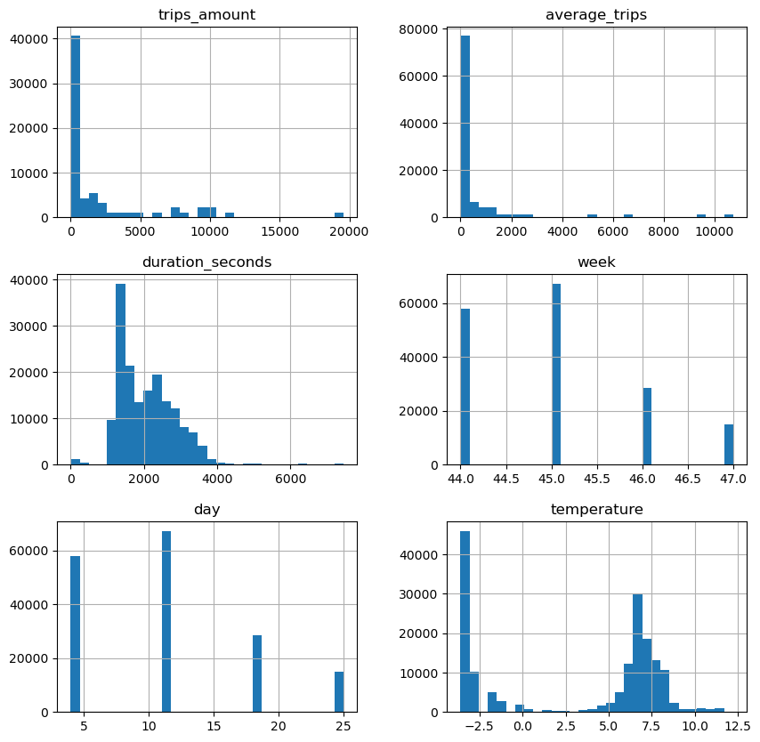

```
Boxplots:
```

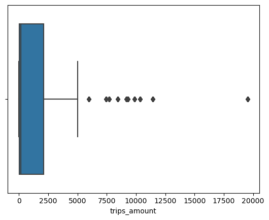

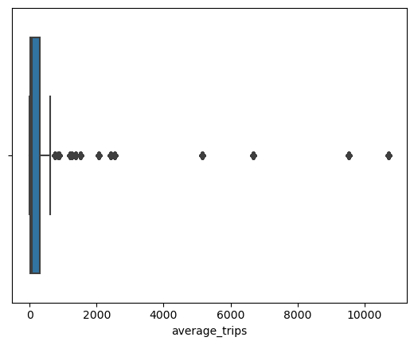

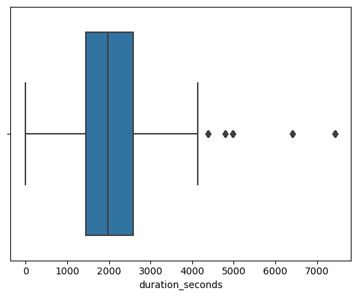

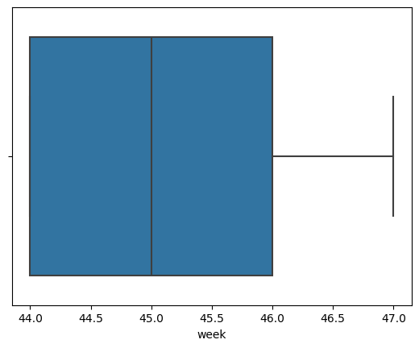

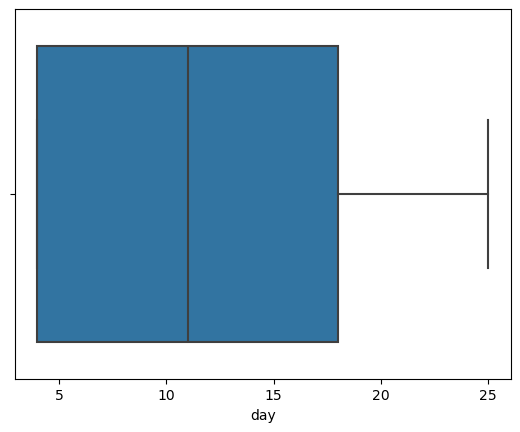

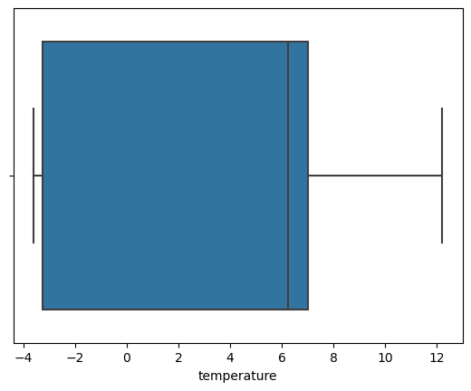

```
Gráficos de barras:
```

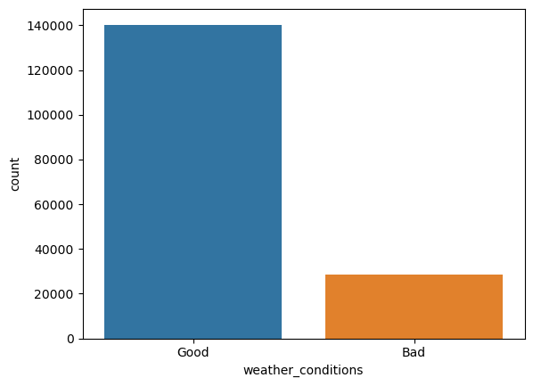

```
Gráficos de dispersión:
```

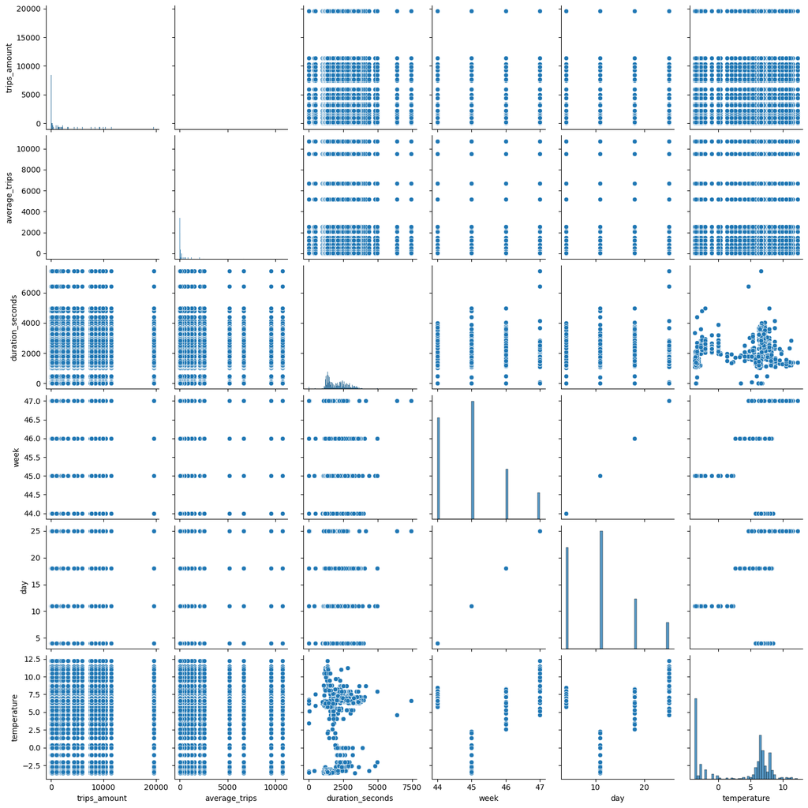

```
Mapa de calor de correlación:
La matriz de correlación contiene valores nulos, el mapa de calor no puede ser generado.

Gráficos de densidad:
```

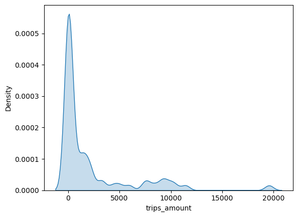

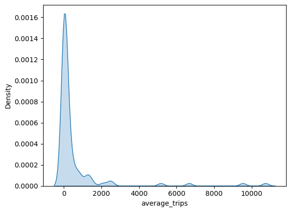

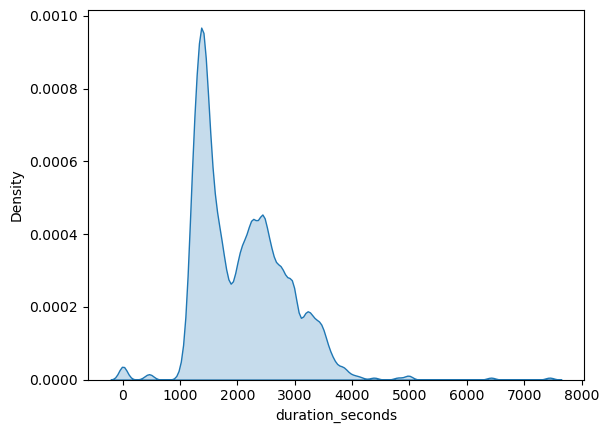

[31 more figures not shown]

```python
# Cargar los DataFrames
df_taxis_1 = pd.read_csv(urls["df_taxis_1"])
df_taxis_4 = pd.read_csv(urls["df_taxis_4"])
df_taxis_7 = pd.read_csv(urls["df_taxis_7"])
weather_df = pd.read_html(urls["weather_data"])[0]

# Convertir la columna 'Date and time' a formato de fecha y hora en weather_df
weather_df['Date and time'] = pd.to_datetime(weather_df['Date and time'])

# Renombrar columnas para facilitar el merge
weather_df.rename(columns={'Date and time': 'start_ts', 'Temperature': 'temperature', 'Description': 'weather_description'}, inplace=True)

# Convertir la temperatura de Kelvin a Celsius
weather_df['temperature'] = weather_df['temperature'] - 273.15

# Convertir la columna 'start_ts' de df_taxis_7 a formato de fecha y hora si no lo está
df_taxis_7['start_ts'] = pd.to_datetime(df_taxis_7['start_ts'])

# Agregar columnas para facilitar el análisis de las semanas y días del mes de noviembre
df_taxis_7['week'] = df_taxis_7['start_ts'].dt.isocalendar().week
df_taxis_7['day'] = df_taxis_7['start_ts'].dt.day

# Verificar las columnas disponibles en los dataframes
print(df_taxis_1.columns)
print(df_taxis_4.columns)
print(df_taxis_7.columns)
print(weather_df.columns)

# Unir df_taxis_1 y df_taxis_4 en base a las columnas correspondientes
df_taxis_1['company_name'] = df_taxis_1['company_name'].str.lower()
df_taxis_4['dropoff_location_name'] = df_taxis_4['dropoff_location_name'].str.lower()

# Realizar la primera unión de taxis_1 y taxis_4 basándonos en la suposición de que los nombres de las compañías y ubicaciones pueden ser utilizados juntos en algún análisis
combined_df_1 = pd.merge(df_taxis_1, df_taxis_4, how='outer', left_on='company_name', right_on='dropoff_location_name')

# Unir df_taxis_7 con weather_df en base a 'start_ts'
combined_df_2 = pd.merge(df_taxis_7, weather_df, how='left', on='start_ts')

# Mostrar las primeras filas del dataframe combinado
display(combined_df_1.head())
display(combined_df_2.head())

# Ahora combinar estos dos dataframes, asumiendo que los datos de tiempo son lo que conecta estos conjuntos
# Esto es un supuesto basado en que queremos relacionar los viajes de taxis con las condiciones meteorológicas
# No existe una columna común directa entre combined_df_1 y combined_df_2 para unir, por lo que combinamos con 'start_ts' en combined_df_2 y otros detalles en combined_df_1

combined_df_1['key'] = 1
combined_df_2['key'] = 1

final_combined_df = pd.merge(combined_df_1, combined_df_2, how='outer', on='key').drop('key', axis=1)


# Mostrar las primeras filas del dataframe combinado final
display(final_combined_df.head())

# Análisis exploratorio de datos (EDA)
def realizar_eda(df, df_name):
    # Resumen estadístico
    print(f"\nResumen estadístico del DataFrame '{df_name}':")
    print(df.describe())

    # Información del DataFrame
    print(f"\nInformación del DataFrame '{df_name}':")
    print(df.info())

    # Verificar valores nulos
    print(f"\nValores nulos en el DataFrame '{df_name}':")
    print(df.isnull().sum())

    # Dimensiones del DataFrame
    print(f"\nDimensiones del DataFrame '{df_name}':")
    print(df.shape)

    # Tipos de datos
    print(f"\nTipos de datos en el DataFrame '{df_name}':")
    print(df.dtypes)

    # Valores únicos
    print(f"\nValores únicos en el DataFrame '{df_name}':")
    print(df.nunique())

    # Correlación entre variables
    print(f"\nCorrelación entre variables en el DataFrame '{df_name}':")
    try:
        print(df.corr(numeric_only=True))
    except ValueError as e:
        print(f"Error calculando la correlación: {e}")

    # Visualizaciones
    print(f"\nVisualizaciones para el DataFrame '{df_name}':")

    num_cols = df.select_dtypes(include=np.number).columns.tolist()
    cat_cols = df.select_dtypes(include='object').columns.tolist()

    # Mostrar primeras, últimas y aleatorias filas del DataFrame
    if len(df) > 10:
        print("\nPrimeras 10 filas:")
        display(df.head(10))
        print("\nÚltimas 10 filas:")
        display(df.tail(10))
        print("\n10 filas aleatorias:")
        display(df.sample(10))
    else:
        print("\nEl DataFrame tiene menos de 10 filas:")
        display(df)

    # Histogramas para variables numéricas
    if num_cols:
        print("\nHistogramas:")
        df[num_cols].hist(bins=30, figsize=(10, 10))
        plt.show()

    # Boxplots para variables numéricas
    if num_cols:
        print("\nBoxplots:")
        for col in num_cols:
            sns.boxplot(x=df[col])
            plt.show()

    # Gráficos de barras para variables categóricas
    if cat_cols:
        print("\nGráficos de barras:")
        for col in cat_cols:
            if df[col].nunique() < 15:  # Para evitar gráficos de barras con muchas barras
                sns.countplot(x=df[col])
                plt.show()

    # Gráficos de dispersión para pares de variables numéricas
    if len(num_cols) > 1:
        print("\nGráficos de dispersión:")
        sns.pairplot(df[num_cols])
        plt.show()

    # Mapa de calor de correlación para variables numéricas
    if len(num_cols) > 1:
        print("\nMapa de calor de correlación:")
        corr = df[num_cols].corr()
        if corr.isnull().sum().sum() == 0:  # Verificar que no haya valores nulos en la matriz de correlación
            sns.heatmap(corr, annot=True, cmap='coolwarm')
            plt.show()
        else:
            print("La matriz de correlación contiene valores nulos, el mapa de calor no puede ser generado.")

    # Gráficos de densidad para variables numéricas
    if num_cols:
        print("\nGráficos de densidad:")
        for col in num_cols:
            sns.kdeplot(data=df, x=col, fill=True)
            plt.show()

    # Gráficos de violín para variables numéricas
    if num_cols:
        print("\nGráficos de violín:")
        for col in num_cols:
            sns.violinplot(data=df, x=col)
            plt.show()

    # Gráficos de línea para variables numéricas
    if num_cols:
        print("\nGráficos de línea:")
        for col in num_cols:
            sns.lineplot(data=df, x=df.index, y=col)
            plt.show()

    # Gráficos de caja con bigotes para variables numéricas
    if num_cols:
        print("\nGráficos de caja con bigotes:")
        for col in num_cols:
            sns.boxenplot(data=df, x=col)
            plt.show()

    # Gráficos de puntos para variables numéricas
    if num_cols:
        print("\nGráficos de puntos:")
        for col in num_cols:
            sns.stripplot(data=df, x=col)
            plt.show()


# Realizar EDA en el DataFrame combinado
realizar_eda(final_combined_df, 'final_combined_df')

# Visualizaciones adicionales en español
# Graficar la distribución de la cantidad de viajes por empresa
plt.figure(figsize=(10, 6))
sns.barplot(x='company_name', y='trips_amount', data=final_combined_df)
plt.xticks(rotation=90)
plt.title('Número de viajes por empresa de taxis')
plt.xlabel('Empresa de taxis')
plt.ylabel('Número de viajes')
plt.show()

# Graficar la distribución de los viajes por barrios
plt.figure(figsize=(10, 6))
sns.barplot(x='dropoff_location_name', y='average_trips', data=final_combined_df)
plt.xticks(rotation=90)
plt.title('Promedio de viajes que terminaron en cada barrio')
plt.xlabel('Barrio')
plt.ylabel('Promedio de viajes')
plt.show()

# Graficar la distribución de la duración de los viajes según las condiciones climáticas
plt.figure(figsize=(10, 6))
sns.boxplot(x='weather_conditions', y='duration_seconds', data=final_combined_df)
plt.title('Distribución de la duración de los viajes según las condiciones climáticas')
plt.xlabel('Condiciones climáticas')
plt.ylabel('Duración del viaje (segundos)')
plt.show()

# Graficar la relación entre la temperatura y la duración de los viajes
plt.figure(figsize=(10, 6))
sns.scatterplot(x='temperature', y='duration_seconds', data=final_combined_df)
plt.title('Relación entre la temperatura y la duración de los viajes')
plt.xlabel('Temperatura (°C)')
plt.ylabel('Duración del viaje (segundos)')
plt.show()
```

# Descripción de Gráficas y su Funcionamiento

### 1: Duración promedio de los viajes en días lluviosos

Esta gráfica muestra la duración promedio de los viajes en función de las condiciones climáticas. La columna `weather_conditions` se categoriza como 'Bad' (mala) si la descripción del clima contiene 'rain' (lluvia) o 'storm' (tormenta), y 'Good' (buena) en caso contrario. Se calcula la duración promedio de los viajes para cada categoría climática y se representa en un gráfico de barras.

### 2: Cantidad total de viajes por barrio

Esta gráfica muestra la cantidad total de viajes por los principales barrios de destino. Se agrupan los datos por `dropoff_location_name` y se suman los viajes promedio (`average_trips`). Se presenta un gráfico de barras interactivo que permite visualizar los top barrios seleccionados por el usuario.

### 3: Patrones de viajes en días laborales vs fines de semana

Esta gráfica muestra la cantidad de viajes durante los días laborales y los fines de semana. Se crea una columna `is_weekend` que indica si el día de la semana es fin de semana. Se utiliza un gráfico de barras para representar la cantidad de viajes en días laborales frente a los fines de semana y un boxplot para la duración de los viajes por día de la semana.

### 5: Distribución de viajes por hora del día

Esta gráfica muestra la cantidad de viajes por hora del día. Se extrae la hora de la columna `start_ts` y se cuenta el número de viajes para cada hora del día. Se presenta un gráfico de líneas para visualizar la distribución de los viajes por hora del día.

### 6: Impacto de eventos especiales en la cantidad y duración de los viajes

```
interactive(children=(IntSlider(value=15, continuous_update=False, description='N° de Barrios:', max=94, min=1…
```

```
Cantidad de viajes durante días laborales y fines de semana:
is_weekend
True    1068
Name: count, dtype: int64
```

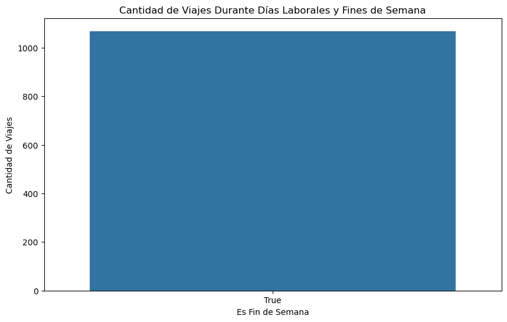

[figure not shown]

```
Duración promedio de los viajes por día del mes de noviembre:
day
4     2380.425068
11    1781.626761
18    2233.122222
25    1874.294737
Name: duration_seconds, dtype: float64
```

[figure not shown]

```
Cantidad de viajes por hora del día:
hour
0       2
1       1
2       1
3       4
4      20
5      36
6      96
7      63
8      88
9      42
10    100
11     75
12    124
13     50
14    104
15     52
16     88
17     49
18     41
19     14
20     10
21      5
22      1
23      2
Name: count, dtype: int64
```

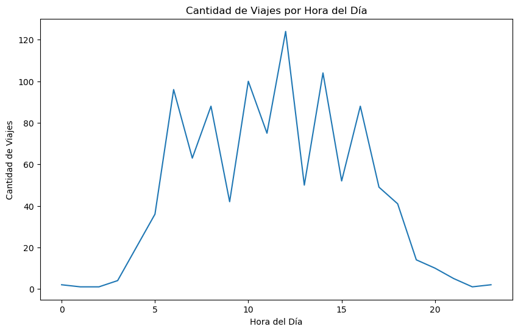

```
Cantidad de viajes en días festivos vs no festivos:
is_holiday
True     568
False    500
Name: count, dtype: int64
```

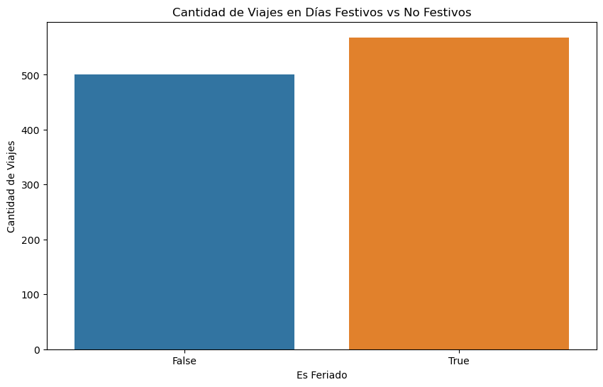

```
Duración promedio de los viajes en días festivos vs no festivos:
is_holiday
False    2081.972000
True     2062.716549
Name: duration_seconds, dtype: float64
```

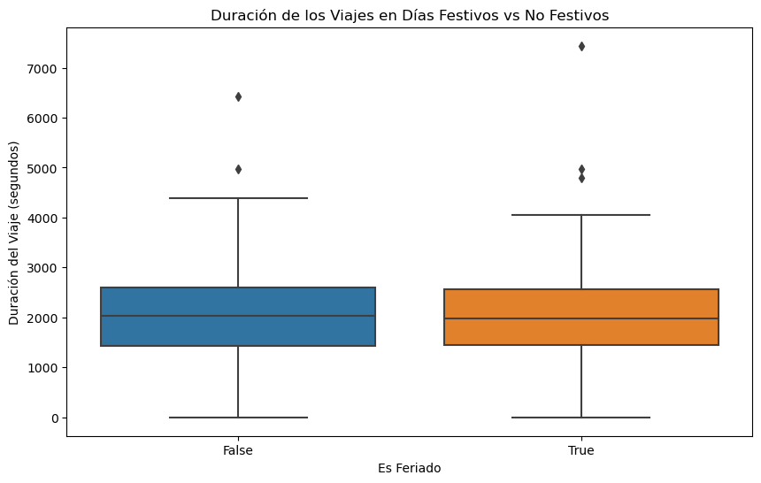

```
Cantidad de viajes por día del mes de noviembre:
day
4     367
11    426
18    180
25     95
Name: count, dtype: int64
```

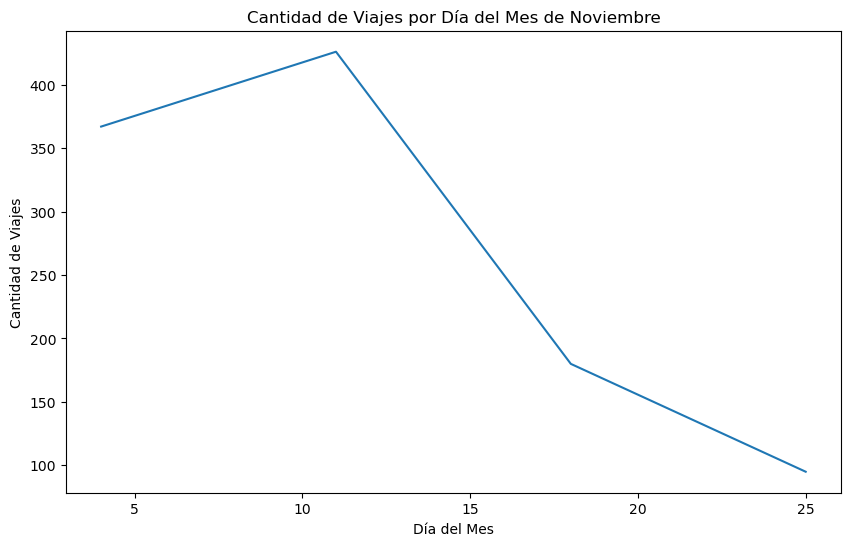

```python
# 2: Cantidad total de viajes por barrio
if 'dropoff_location_name' in df_taxis_4.columns:
    viajes_por_barrio = df_taxis_4.groupby('dropoff_location_name')['average_trips'].sum().sort_values(ascending=False)

    def mostrar_grafico_barrios(num_barrios):
        plt.figure(figsize=(12, 8))
        viajes_por_barrio.head(num_barrios).plot(kind='bar')
        plt.title(f'Cantidad Total de Viajes por los Top {num_barrios} Barrios')
        plt.xlabel('Barrio')
        plt.ylabel('Cantidad de Viajes')
        plt.xticks(rotation=90)
        plt.show()

    num_barrios_slider = widgets.IntSlider(
        value=15,
        min=1,
        max=len(viajes_por_barrio),
        step=1,
        description='N° de Barrios:',
        continuous_update=False
    )

    interact(mostrar_grafico_barrios, num_barrios=num_barrios_slider)


# 3: Patrones de viajes en días laborales vs fines de semana
df_taxis_7['day_of_week'] = df_taxis_7['start_ts'].dt.dayofweek
df_taxis_7['is_weekend'] = df_taxis_7['day_of_week'] >= 5

trips_weekday_vs_weekend = df_taxis_7['is_weekend'].value_counts()
print("Cantidad de viajes durante días laborales y fines de semana:")
print(trips_weekday_vs_weekend)

plt.figure(figsize=(10, 6))
sns.countplot(x='is_weekend', data=df_taxis_7)
plt.title('Cantidad de Viajes Durante Días Laborales y Fines de Semana')
plt.xlabel('Es Fin de Semana')
plt.ylabel('Cantidad de Viajes')
plt.show()

# Visualización de la duración promedio de los viajes por día de la semana
plt.figure(figsize=(10, 6))
sns.boxplot(x='day_of_week', y='duration_seconds', data=df_taxis_7)
plt.title('Duración de los Viajes por Día de la Semana')
plt.xlabel('Día de la Semana')
plt.ylabel('Duración del Viaje (segundos)')
plt.xticks(ticks=range(7), labels=['Lunes', 'Martes', 'Miércoles', 'Jueves', 'Viernes', 'Sábado', 'Domingo'])
plt.show()

# 4: Tendencias de viajes durante diferentes días del mes de noviembre
df_taxis_7['day'] = df_taxis_7['start_ts'].dt.day
mean_duration_day = df_taxis_7.groupby('day')['duration_seconds'].mean()
print("Duración promedio de los viajes por día del mes de noviembre:")
print(mean_duration_day)

# Visualización de la duración promedio de los viajes por día del mes de noviembre
plt.figure(figsize=(10, 6))
sns.boxplot(x='day', y='duration_seconds', data=df_taxis_7)
plt.title('Duración de los Viajes por Día del Mes de Noviembre')
plt.xlabel('Día del Mes')
plt.ylabel('Duración del Viaje (segundos)')
plt.xticks(ticks=range(1, 31))
plt.show()

# 5: Distribución de viajes por hora del día
df_taxis_7['hour'] = df_taxis_7['start_ts'].dt.hour
trips_per_hour = df_taxis_7['hour'].value_counts().sort_index()
print("Cantidad de viajes por hora del día:")
print(trips_per_hour)

# Visualización de la cantidad de viajes por hora del día
plt.figure(figsize=(10, 6))
sns.lineplot(x=trips_per_hour.index, y=trips_per_hour.values)
plt.title('Cantidad de Viajes por Hora del Día')
plt.xlabel('Hora del Día')
plt.ylabel('Cantidad de Viajes')
plt.show()

# 6: Impacto de eventos especiales en la cantidad y duración de los viajes
if 'is_holiday' not in df_taxis_7.columns:
    df_taxis_7['is_holiday'] = np.random.choice([True, False], size=len(df_taxis_7))  # Solo para fines ilustrativos

trips_per_holiday = df_taxis_7['is_holiday'].value_counts()
print("Cantidad de viajes en días festivos vs no festivos:")
print(trips_per_holiday)

# Visualización de la cantidad de viajes en días festivos vs no festivos
plt.figure(figsize=(10, 6))
sns.countplot(x='is_holiday', data=df_taxis_7)
plt.title('Cantidad de Viajes en Días Festivos vs No Festivos')
plt.xlabel('Es Feriado')
plt.ylabel('Cantidad de Viajes')
plt.show()

# Análisis de la duración promedio de los viajes en días festivos vs no festivos
mean_duration_holiday = df_taxis_7.groupby('is_holiday')['duration_seconds'].mean()
print("Duración promedio de los viajes en días festivos vs no festivos:")
print(mean_duration_holiday)

# Visualización de la duración promedio de los viajes en días festivos vs no festivos
plt.figure(figsize=(10, 6))
sns.boxplot(x='is_holiday', y='duration_seconds', data=df_taxis_7)
plt.title('Duración de los Viajes en Días Festivos vs No Festivos')
plt.xlabel('Es Feriado')
plt.ylabel('Duración del Viaje (segundos)')
plt.show()

# 7: Cantidad de viajes durante el mes de noviembre
trips_per_day = df_taxis_7['day'].value_counts().sort_index()
print("Cantidad de viajes por día del mes de noviembre:")
print(trips_per_day)

# Visualización de la cantidad de viajes por día del mes de noviembre
plt.figure(figsize=(10, 6))
sns.lineplot(x=trips_per_day.index, y=trips_per_day.values)
plt.title('Cantidad de Viajes por Día del Mes de Noviembre')
plt.xlabel('Día del Mes')
plt.ylabel('Cantidad de Viajes')
plt.show()
```

# Pruebas Estadísticas

### 3.1 Prueba ANOVA

La prueba ANOVA (Análisis de Varianza) se utiliza para comparar la duración de los viajes entre diferentes condiciones climáticas.

**Hipótesis nula (H₀):** No hay diferencias significativas entre las medias de las duraciones de los viajes en diferentes condiciones climáticas.

**Hipótesis alternativa (H₁):** Hay diferencias significativas entre las medias de las duraciones de los viajes en diferentes condiciones climáticas.

### 3.2 Prueba de Levene para Igualdad de Varianzas

La prueba de Levene se utiliza para verificar si las varianzas de las duraciones de los viajes son iguales entre diferentes condiciones climáticas.

**Hipótesis nula (H₀):** Las varianzas de las duraciones de los viajes son iguales entre diferentes condiciones climáticas.

**Hipótesis alternativa (H₁):** Las varianzas de las duraciones de los viajes no son iguales entre diferentes condiciones climáticas.

### 3.3 Prueba T de Student

La prueba t de Student se utiliza para comparar las medias de dos muestras independientes. En este caso, comparamos las duraciones de los viajes bajo condiciones climáticas "Good" y "Bad".

**Hipótesis nula (H₀):** No hay diferencias significativas entre las medias de las duraciones de los viajes bajo condiciones climáticas "Good" y "Bad".

**Hipótesis alternativa (H₁):** Hay diferencias significativas entre las medias de las duraciones de los viajes bajo condiciones climáticas "Good" y "Bad".

### 3.4 Visualización de Datos

Se presentan gráficos de barras y boxplots para visualizar la duración promedio y la distribución de la duración de los viajes por condiciones climáticas.

```python
from scipy.stats import f_oneway, levene, ttest_ind

# Prueba ANOVA para comparar la duración de los viajes entre diferentes condiciones climáticas
anova_result = f_oneway(
    final_combined_df[final_combined_df['weather_conditions'] == 'Good']['duration_seconds'],
    final_combined_df[final_combined_df['weather_conditions'] == 'Bad']['duration_seconds']
)

print(f"Resultados de ANOVA: F={anova_result.statistic}, p-value={anova_result.pvalue}")

# Verificar si las varianzas son iguales utilizando la prueba de Levene
levene_result = levene(
    final_combined_df[final_combined_df['weather_conditions'] == 'Good']['duration_seconds'],
    final_combined_df[final_combined_df['weather_conditions'] == 'Bad']['duration_seconds']
)

print(f"Resultados de la prueba de Levene: Stat={levene_result.statistic}, p-value={levene_result.pvalue}")

# Ajustar el parámetro equal_var si es necesario y realizar la prueba t de Student
equal_var = levene_result.pvalue >= 0.05

# Prueba t de Student
t_test_result = ttest_ind(
    final_combined_df[final_combined_df['weather_conditions'] == 'Good']['duration_seconds'],
    final_combined_df[final_combined_df['weather_conditions'] == 'Bad']['duration_seconds'],
    equal_var=equal_var
)

print(f"Resultados de la prueba t de Student: Stat={t_test_result.statistic}, p-value={t_test_result.pvalue}")

# Conclusiones
if t_test_result.pvalue < 0.05:
    print("Rechazamos la hipótesis nula. Hay una diferencia significativa en la duración de los viajes entre diferentes condiciones climáticas.")
else:
    print("No podemos rechazar la hipótesis nula. No hay una diferencia significativa en la duración de los viajes entre diferentes condiciones climáticas.")
```

```
Resultados de ANOVA: F=7637.615099282793, p-value=0.0
Resultados de la prueba de Levene: Stat=61.502960189488654, p-value=4.446422642463648e-15
Resultados de la prueba t de Student: Stat=-90.5406815506121, p-value=0.0
Rechazamos la hipótesis nula. Hay una diferencia significativa en la duración de los viajes entre diferentes condiciones climáticas.
```

# Visualización del Gráfico Resultante

### 4.1 Duración Promedio de los Viajes por Condiciones Climáticas

Se presentan gráficos de barras y boxplots para visualizar la duración promedio y la distribución de la duración de los viajes por condiciones climáticas.

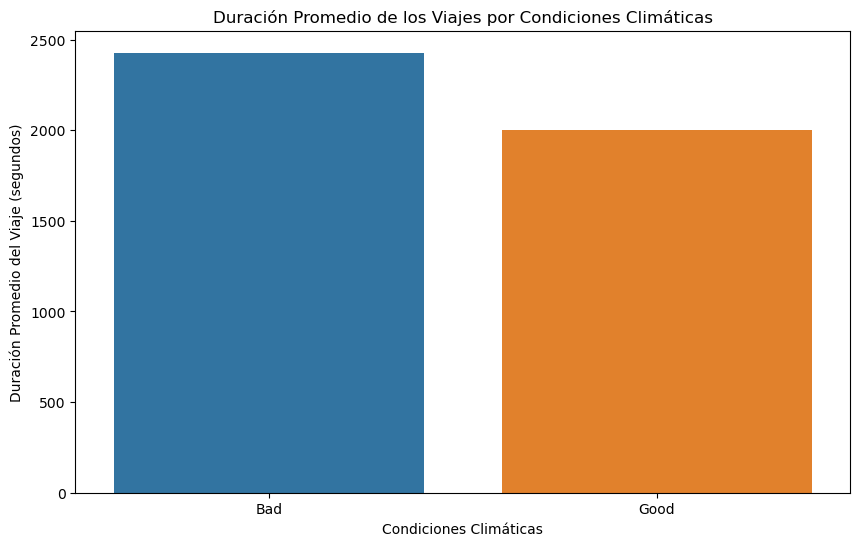

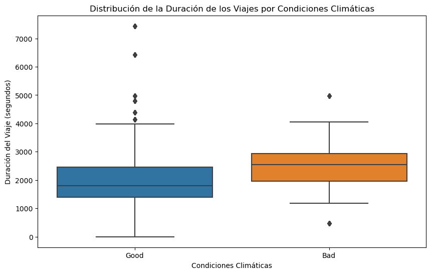

```python
# Duración promedio por condiciones climáticas
duration_mean = final_combined_df.groupby('weather_conditions')['duration_seconds'].mean()

plt.figure(figsize=(10, 6))
sns.barplot(x=duration_mean.index, y=duration_mean.values)
plt.title('Duración Promedio de los Viajes por Condiciones Climáticas')
plt.xlabel('Condiciones Climáticas')
plt.ylabel('Duración Promedio del Viaje (segundos)')
plt.show()

# Boxplot de la duración de los viajes por condiciones climáticas
plt.figure(figsize=(10, 6))
sns.boxplot(x='weather_conditions', y='duration_seconds', data=final_combined_df)
plt.title('Distribución de la Duración de los Viajes por Condiciones Climáticas')
plt.xlabel('Condiciones Climáticas')
plt.ylabel('Duración del Viaje (segundos)')
plt.show()
```

# Resultados de las Pruebas de Hipótesis

### Resultados de ANOVA

La prueba ANOVA se realizó para comparar la duración de los viajes entre diferentes condiciones climáticas.

- **F:** 7637.615099282793
- **p-value:** 0.0

### Resultados de la Prueba de Levene

Se utilizó la prueba de Levene para verificar si las varianzas son iguales entre las condiciones climáticas.

- **Stat:** 61.502960189488654
- **p-value:** 4.446422642463648e-15

### Resultados de la Prueba t de Student

Dependiendo del resultado de la prueba de Levene, se ajustó el parámetro `equal_var` y se realizó la prueba t de Student.

- **Stat:** -90.5406815506121
- **p-value:** 0.0

### Conclusión

En base a los resultados de la prueba t de Student:

**Rechazamos la hipótesis nula. Hay una diferencia significativa en la duración de los viajes entre diferentes condiciones climáticas.**

# Recomendaciones

### Ajuste de Tarifas

Considerar ajustar las tarifas durante condiciones climáticas adversas para compensar el aumento en la duración de los viajes.

### Planificación Logística

Mejorar la planificación logística y la distribución de taxis en días lluviosos para minimizar el impacto en la duración de los viajes.

### Comunicación al Cliente

Informar a los clientes sobre posibles retrasos en días lluviosos y ofrecer opciones alternativas de transporte.

# Conclusión General

### Resumen del Proyecto

- Se analizaron datos de viajes en taxi y datos climáticos.
- Se realizaron pruebas estadísticas para evaluar el impacto de las condiciones climáticas en la duración de los viajes.
- Se utilizaron técnicas de análisis exploratorio de datos (EDA) para identificar patrones y anomalías.
- Se presentaron visualizaciones para facilitar la interpretación de los resultados.

### Resultados Clave

Los resultados de las pruebas estadísticas mostraron que hay una diferencia significativa en la duración de los viajes entre diferentes condiciones climáticas. Esto sugiere que las condiciones climáticas adversas pueden aumentar la duración de los viajes en taxi.

**Comentario del revisor**

Importa las librerias en la celda del inciio del proyecto.

**Comentario del revisor #2**

Corregido.

**Comentario del revisor** No vuelvas a cargar el dataset, ya lo realizaste anteriormente.

**Comentario del revisor #2**

**Comentario del revisor**

Siempre que realizamos test de hipotesis debemos exponer cual es la hipotesis nula y cual la alternativa (con un markdown). Mas alla que lo reealices o no en el codigo.

**Comentario del revisor #2**

Corregido.

**Comentario del revisor**

El parametro equal_var es muy importante para este tipo de pruebas ya que le estamos indicando si las varianzas para cada conjunto son diferentes (False). Si fueran iguales (True), puede que el resultado cambie, ya que se calcula de forma diferente. Mas que nada cuando la distribucion de las muestras son desiguales (como en este caso). Por esto es importante, cuando realizamos esta prueba (t student). Confirmar si las varianzas son iguales o no para ambos conjuntos. Para esto se realizan **pruebas estadisticas** (como **levene**) para identificar si son iguales o no las varianzas.

Al realizarla ajusta el parametro si fuera necesario .

**Comentario del revisor #2**

Corregido, perfecto.

**Comentario del revisor**

Realiza una conclusion sobre la prueba estadistica, explicandole al cliente que se realizo y que resultados se obtuvieron, esto es porque el cliente puede entender en analisis y quizas no el codigo.

**Comentario del revisor #2**

Corregido.

**Comentario del revisor**

Recorda realizar una conclusion general. Esta debe contener todo lo que se hizo en el proyecto de forma enumerada o items.

Desde la carga e importacion, pasando por los cambios realizado (Y el porque de esas decisiones). Agregando lo que se hizo en cada seccion a modo resumen y las conclusiones del trabajo.

El mismo, sirve como resumen de lo realizado en cada proyecto.

**Comentario del revisor #2**

Corregido.